# PhD Chapter 3 - RelativeSize

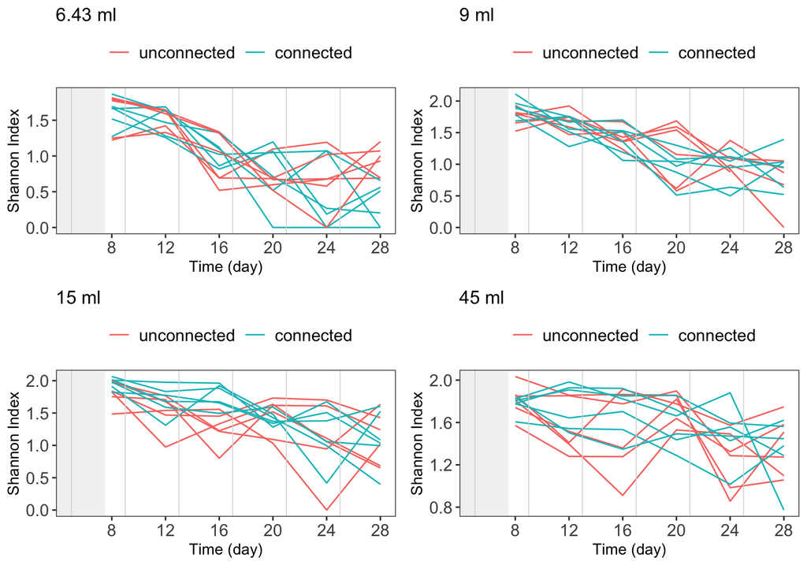

```r
plot.ecosystems.sizes.one.by.one(filtered_data,
                                      trophy_selected,
                                      disturbance_percentage_selected = "decreasing_with_size",
                                      response_variable_selected)
```

```r
# --- CREATE MODEL --- #

# In the ouput lmerModLmerTest which means that it's a Linear Mixed Model from the lmerTest package

model = lmer(
   get(response_variable_selected) ~
     size * conn * disturbance_percentage +
     (1 | ecosystem_ID) +
     (1 | day),
   data = filtered_data %>%
     rename(size = ecosystem_size_ml) %>%
     mutate(conn = factor(x = ifelse(connection == "connected",
                                     "con",
                                     "unconnected"),
                          levels = c("unconnected", "con"))),
   REML = FALSE,
   control = lmerControl(optimizer = "Nelder_Mead"))
```

**Model summary**

```r
# --- SHOW MODEL SUMMARY --- #

print(summary(model), digits = 3)
```

```
## Linear mixed model fit by maximum likelihood . t-tests use Satterthwaite's
##   method [lmerModLmerTest]
## Formula:
## get(response_variable_selected) ~ size * conn * disturbance_percentage +
##     (1 | ecosystem_ID) + (1 | day)
##    Data:
## filtered_data %>% rename(size = ecosystem_size_ml) %>% mutate(conn = factor(x = ifelse(connection ==
##     "connected", "con", "unconnected"), levels = c("unconnected",      "con")))
## Control: lmerControl(optimizer = "Nelder_Mead")
##
##      AIC      BIC   logLik deviance df.resid
##    510.0    557.7   -244.0    488.0      555
##
## Scaled residuals:
##    Min     1Q Median     3Q    Max
## -3.624 -0.577  0.109  0.635  2.486
##
## Random effects:
##  Groups       Name        Variance Std.Dev.
##  ecosystem_ID (Intercept) 0.00512  0.0716
##  day          (Intercept) 0.10978  0.3313
##  Residual                 0.12771  0.3574
## Number of obs: 566, groups:  ecosystem_ID, 96; day, 6
##
## Fixed effects:
##                                          Estimate Std. Error       df t value
## (Intercept)                               1.15653    0.14532  7.78896    7.96
## size                                      0.00909    0.00216 94.59630    4.20
## conncon                                  -0.05432    0.07479 95.84891   -0.73
## disturbance_percentagefixed              -0.34378    0.07520 97.44890   -4.57
## size:conncon                              0.00333    0.00305 94.05917    1.09
## size:disturbance_percentagefixed         -0.00503    0.00306 94.54346   -1.64
## conncon:disturbance_percentagefixed       0.03494    0.10596 96.30943    0.33
## size:conncon:disturbance_percentagefixed  0.00305    0.00432 94.19216    0.71
##                                          Pr(>|t|)
## (Intercept)                               5.3e-05 ***
## size                                      6.0e-05 ***
## conncon                                      0.47
## disturbance_percentagefixed               1.4e-05 ***
## size:conncon                                 0.28
## size:disturbance_percentagefixed             0.10
## conncon:disturbance_percentagefixed          0.74
## size:conncon:disturbance_percentagefixed     0.48
## ---
## Signif. codes:  0 '***' 0.001 '**' 0.01 '*' 0.05 '.' 0.1 ' ' 1
##
## Correlation of Fixed Effects:
##             (Intr) size   conncn dstrb_ sz:cnn sz:ds_ cnnc:_
## size        -0.284
## conncon     -0.260  0.551
## dstrbnc_prc -0.258  0.548  0.502
## size:conncn  0.201 -0.708 -0.776 -0.388
## sz:dstrbnc_  0.201 -0.707 -0.390 -0.776  0.501
## cnncn:dstr_  0.183 -0.389 -0.706 -0.710  0.548  0.551
## sz:cnncn:d_ -0.142  0.501  0.548  0.550 -0.707 -0.708 -0.776
```

**Model ANOVA**

```r
# --- SHOW MODEL ANOVA --- #

anova(model)
```

```
## Type III Analysis of Variance Table with Satterthwaite's method
##                                  Sum Sq Mean Sq NumDF  DenDF F value    Pr(>F)
## size                             8.8577  8.8577     1 94.229 69.3565 6.417e-13
## conn                             0.0618  0.0618     1 96.303  0.4838   0.48837
## disturbance_percentage           4.8443  4.8443     1 96.331 37.9315 1.690e-08
## size:conn                        0.6445  0.6445     1 94.191  5.0463   0.02702
## size:disturbance_percentage      0.3354  0.3354     1 94.198  2.6263   0.10845
## conn:disturbance_percentage      0.0139  0.0139     1 96.309  0.1087   0.74229
## size:conn:disturbance_percentage 0.0635  0.0635     1 94.192  0.4975   0.48234
##
## size                             ***
## conn
## disturbance_percentage           ***
## size:conn                        *
## size:disturbance_percentage
## conn:disturbance_percentage
## size:conn:disturbance_percentage
## ---
## Signif. codes:  0 '***' 0.001 '**' 0.01 '*' 0.05 '.' 0.1 ' ' 1
```

**Model residuals**

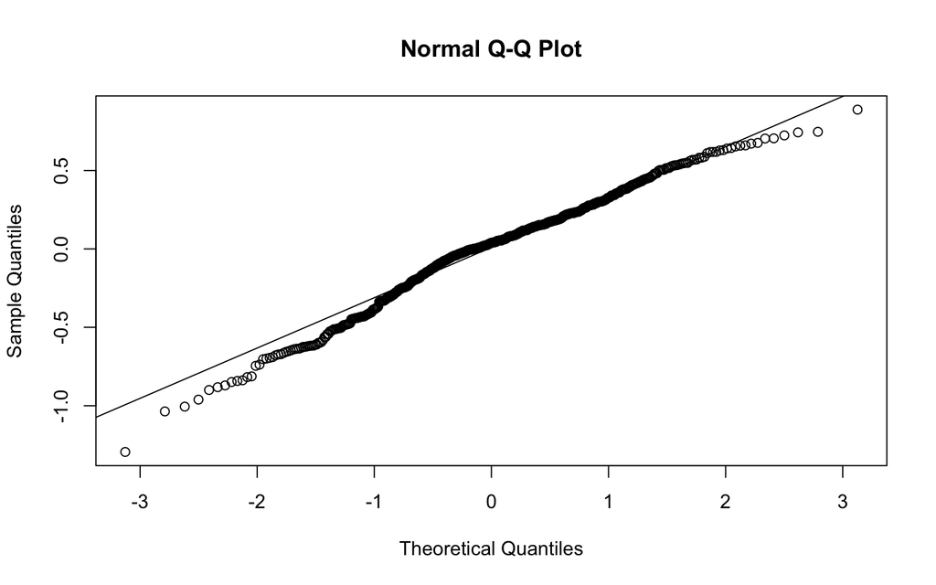

```r
# --- PLOT MODEL RESIDUALS --- #

qqnorm(resid(model))
qqline(resid(model))
```

```r
create.res.vs.fit.ecosystems(model,
                             filtered_data)
```

[interactive chart not shown]

### Evenness

```r
response_variable_selected = "evenness_pielou"
```

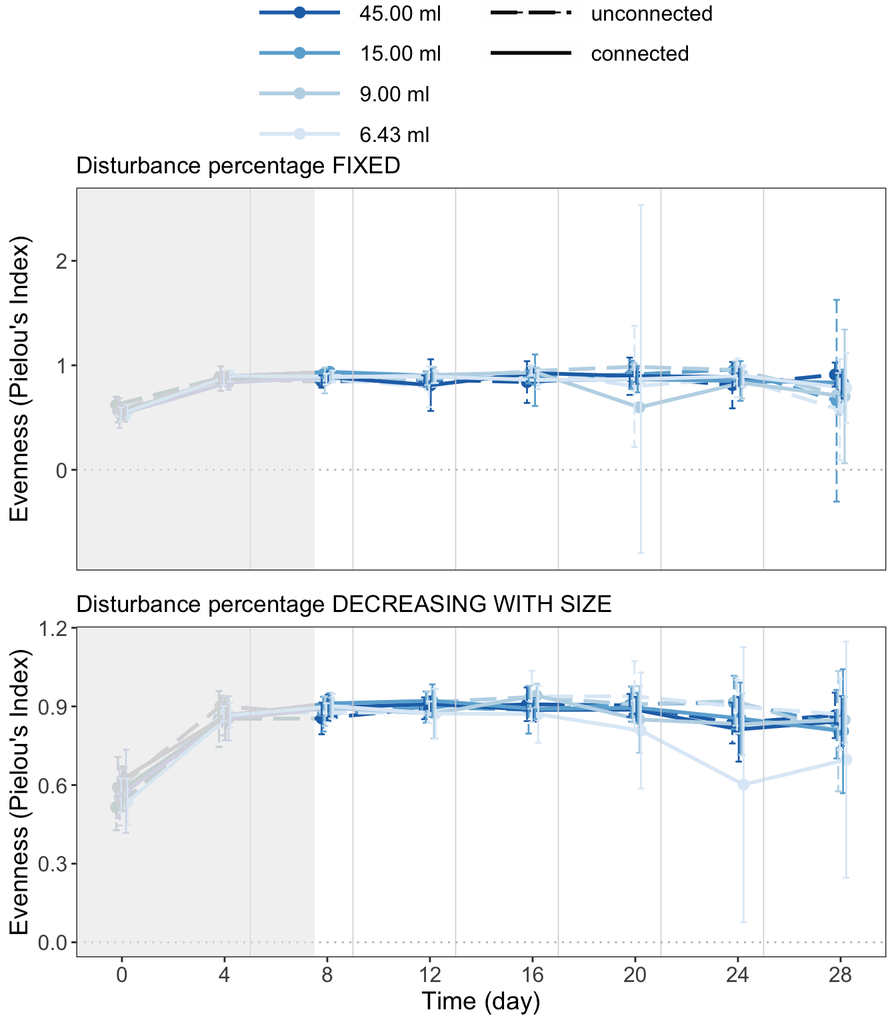

```r
# --- PLOT ORIGINAL DATA MEAN ± 95 % CI --- #

for(trophy_selected in c("autotrophic", "heterotrophic")) {

  if(trophy_selected == "autotrophic" & response_variable_selected == "evenness_pielou"){
    next
  }

  ggarrange(plot.ecosystems.points.legend(ds_ecosystems %>%
                                            filter(disturbance_percentage == "fixed"),
                                          trophy_selected,
                                          response_variable_selected,
                                          legend_row_n_input = 4),
            plot.ecosystems.points(ds_ecosystems %>%
                                     filter(disturbance_percentage == "fixed"),
                                   trophy_selected,
                                   response_variable_selected,
                                   legend_row_n_input = 4)  +
            rremove("xlab") +
            theme(axis.text.x = element_blank(),
                  axis.ticks.x = element_blank(),
                  legend.position = "none") +
            font("legend.text", size = size_legend) +
            font("ylab", size = size_y_axis) +
            ggtitle(fixed_label),
          plot.ecosystems.points(ds_ecosystems %>%
                                   filter(disturbance_percentage == "decreasing_with_size"),
                                 trophy_selected,
                                 response_variable_selected,
                                 legend_row_n_input = 4)  +
            font("xlab", size = size_y_axis) +
            font("ylab", size = size_y_axis) +
            ggtitle(relative_label) +
            scale_x_continuous(breaks = unique(ds_metaecosystems$day)) +
            theme(legend.position = "none"),
          heights = c(0.2, 0.6, 0.6),
          nrow = 3,
          align = "v") %>%
    print()
  }
```

**A plot per ecosystem size, means**

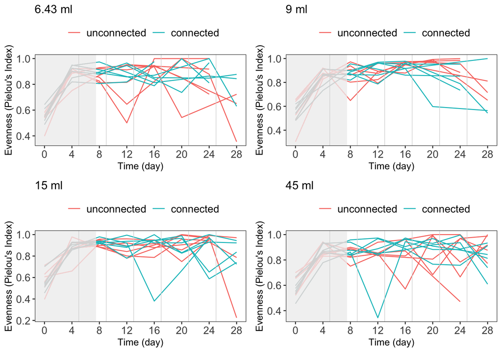

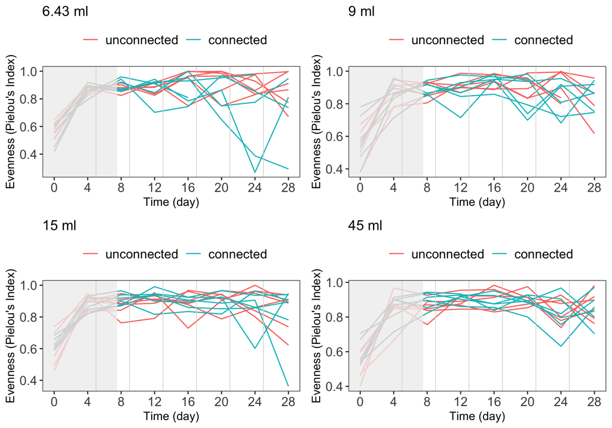

```r
# --- PLOT ORIGINAL DATA MEAN ± 95 % CI WITH ONE PLOT PER ECOSYSTEM SIZE --- #

for(trophy_selected in c("autotrophic", "heterotrophic")) {

  if(trophy_selected == "autotrophic" & response_variable_selected == "evenness_pielou"){
    next
  }

  trophy_selected

  fixed_label
  plot.ecosystems.sizes.one.by.one(ds_ecosystems,
                                   trophy_selected,
                                   disturbance_percentage_selected = "fixed",
                                   response_variable_selected)

  relative_label
  plot.ecosystems.sizes.one.by.one(ds_ecosystems,
                                   trophy_selected,
                                   disturbance_percentage_selected = "decreasing_with_size",
                                   response_variable_selected)
}
```

**A plot per ecosystem size, replicates [WORK IN PROGRESS]**

**Effect sizes using Hedge’s d**

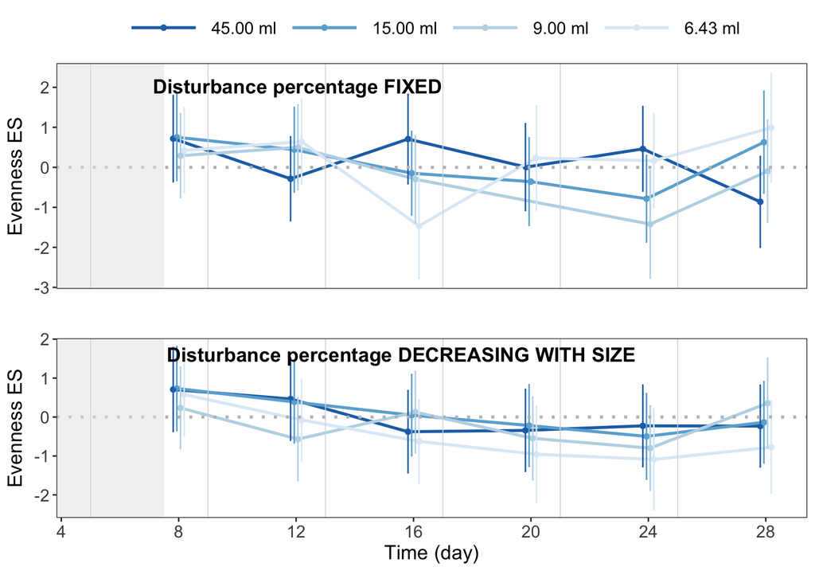

```r
# --- PLOT ORIGINAL DATA EFFECT SIZES (HEDGE'S D) --- #

for(trophy_selected in c("autotrophic", "heterotrophic")) {

  if(trophy_selected == "autotrophic" & response_variable_selected == "evenness_pielou"){
    next
  }

  ggarrange(plot.ecosystems.points.ES(ds_ecosystems_effect_size,
                                    trophy_selected,
                                    "fixed",
                                    paste0(response_variable_selected, "_d")) +
            rremove("xlab") +
            theme(axis.text.x = element_blank(),
                  axis.ticks.x = element_blank()) +
            font("legend.text", size = size_legend) +
            font("ylab", size = size_y_axis),
          NULL,
          plot.ecosystems.points.ES(ds_ecosystems_effect_size,
                                    trophy_selected,
                                    "decreasing_with_size",
                                    paste0(response_variable_selected, "_d"))  +
            font("legend.text", size = size_legend) +
            font("xlab", size = size_y_axis) +
            font("ylab", size = size_y_axis) +
            scale_x_continuous(breaks = unique(ds_metaecosystems$day)) +
            theme(legend.position = "none"),
          heights = c(1, 0.1, 0.8),
          nrow = 3,
          align = "v",
          labels = c(fixed_label, "", relative_label),
          label.x = c(0.01, 0, -0.083),
          label.y = c(0.760, 0, 0.96)) %>%
  print()

  }
```

**Effect sizes using log response ratio**

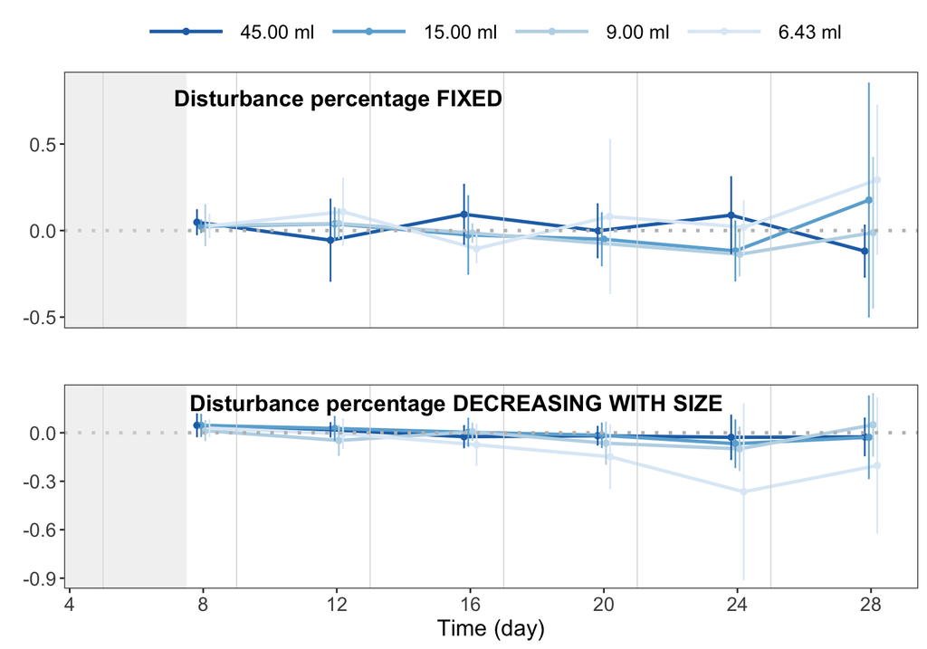

```r
# --- PLOT ORIGINAL DATA EFFECT SIZES (LRR) --- #

for(trophy_selected in c("autotrophic", "heterotrophic")) {

  if(trophy_selected == "autotrophic" & response_variable_selected == "evenness_pielou"){
    next
  }


ggarrange(plot.ecosystems.points.ES(ds_ecosystems_effect_size,
                                    trophy_selected,
                                    "fixed",
                                    paste0(response_variable_selected, "_LRR")) +
            rremove("xlab") +
            theme(axis.text.x = element_blank(),
                  axis.ticks.x = element_blank()) +
            font("legend.text", size = size_legend) +
            font("ylab", size = size_y_axis),
          NULL,
          plot.ecosystems.points.ES(ds_ecosystems_effect_size,
                                    trophy_selected,
                                    "decreasing_with_size",
                                    paste0(response_variable_selected, "_LRR"))  +
            font("legend.text", size = size_legend) +
            font("xlab", size = size_y_axis) +
            font("ylab", size = size_y_axis) +
            scale_x_continuous(breaks = unique(ds_metaecosystems$day)) +
            theme(legend.position = "none"),
          heights = c(1, 0.1, 0.8),
          nrow = 3,
          align = "v",
          labels = c(fixed_label, "", relative_label),
          label.x = c(0.01, 0, -0.083),
          label.y = c(0.760, 0, 0.96)) %>%
    print()
}
```

```r
# --- PREPARE DATA FOR ANALYSIS --- #

filtered_data = ds_ecosystems %>%
  filter(trophic_type == trophy_selected,
         time_point >= first_time_point_model,
         time_point <= last_time_point_model,!is.na(!!sym(response_variable_selected))) %>%
  mutate(ecosystem_ID = as.character(ecosystem_ID))
```

**Filtered data mean ± 95 % CI**

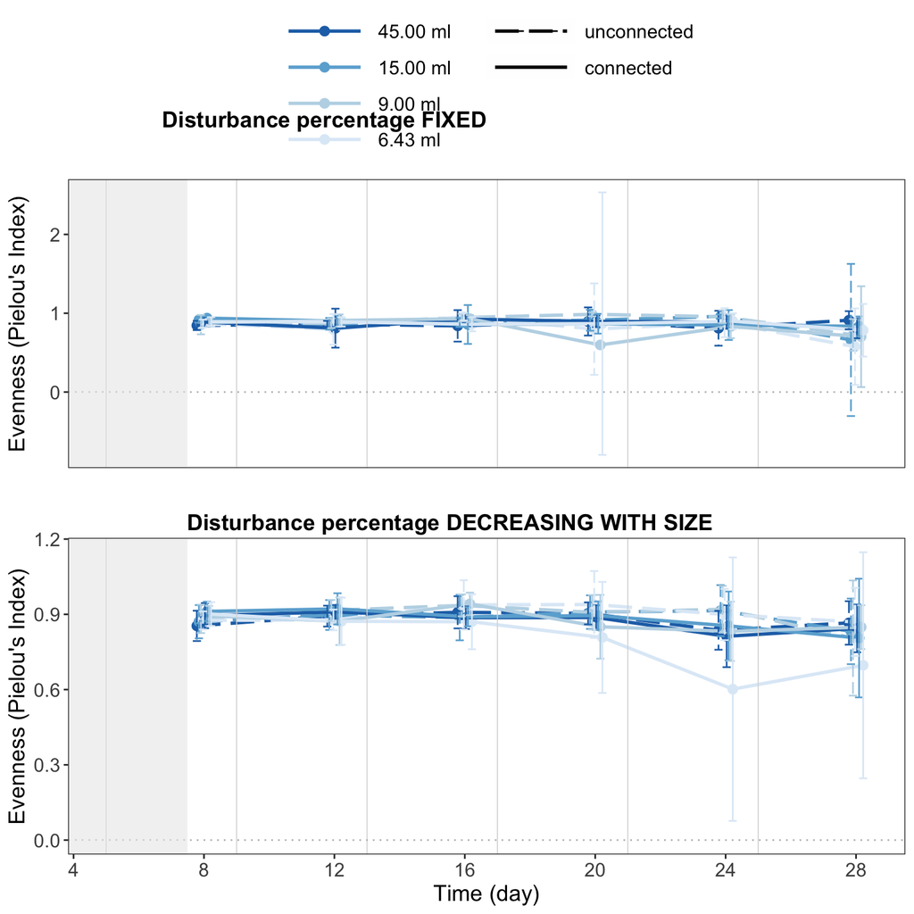

```r
# --- PLOT FILTERED DATA MEAN ± 95 % CI --- #

ggarrange(plot.ecosystems.points(filtered_data %>% filter(disturbance_percentage == "fixed"),
                                 trophy_selected,
                                 response_variable_selected,
                                 legend_row_n_input = 4) +
            rremove("xlab") +
            theme(axis.text.x = element_blank(),
                  axis.ticks.x = element_blank()) +
            font("legend.text", size = size_legend) +
            font("ylab", size = size_y_axis),
          NULL,
          plot.ecosystems.points(filtered_data %>% filter(disturbance_percentage == "decreasing_with_size"),
                                 trophy_selected,
                                 response_variable_selected,
                                 legend_row_n_input = 4) +
            font("legend.text", size = size_legend) +
            font("xlab", size = size_y_axis) +
            font("ylab", size = size_y_axis) +
            scale_x_continuous(breaks = unique(ds_metaecosystems$day)) +
            theme(legend.position = "none"),
          heights = c(1, 0.1, 0.8),
          nrow = 3,
          align = "v",
          labels = c(fixed_label, "", relative_label),
          label.x = c(0, 0, -0.083),
          label.y = c(0.785, 0, 1.06))
```

**Single treatments: for each size connected vs unconnected**

```r
# --- PLOT SINGLE REPLICATES, FOR EACH SIZE A PLOT --- #

fixed_label
```

```
## [1] "Disturbance percentage FIXED"
```

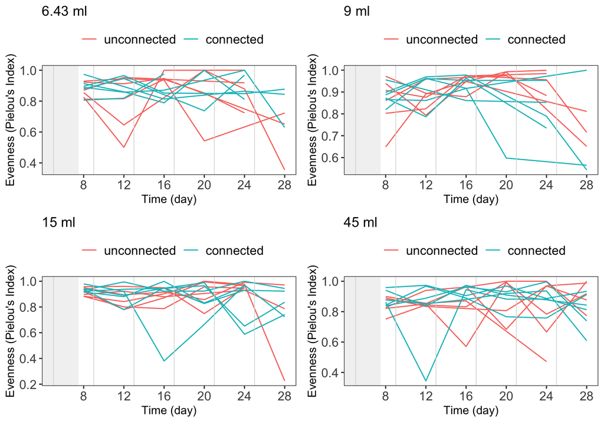

```r
plot.ecosystems.sizes.one.by.one(filtered_data,
                                      trophy_selected,
                                      disturbance_percentage_selected = "fixed",
                                      response_variable_selected)
```

```r
relative_label
```

```
## [1] "Disturbance percentage DECREASING WITH SIZE"
```

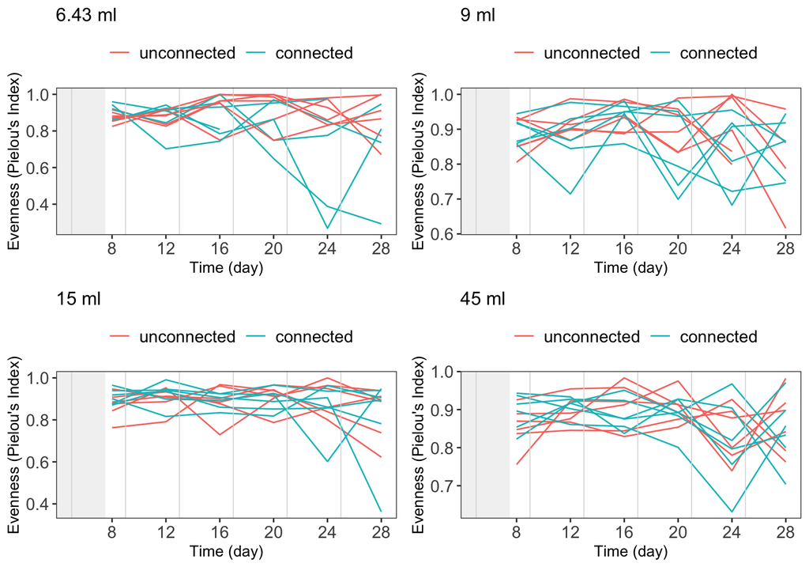

```r
plot.ecosystems.sizes.one.by.one(filtered_data,
                                      trophy_selected,
                                      disturbance_percentage_selected = "decreasing_with_size",
                                      response_variable_selected)
```

```r
# --- CREATE MODEL --- #

# In the ouput lmerModLmerTest which means that it's a Linear Mixed Model from the lmerTest package

model = lmer(
   get(response_variable_selected) ~
     size * conn * disturbance_percentage +
     (1 | ecosystem_ID) +
     (1 | day),
   data = filtered_data %>%
     rename(size = ecosystem_size_ml) %>%
     mutate(conn = factor(x = ifelse(connection == "connected",
                                     "con",
                                     "unconnected"),
                          levels = c("unconnected", "con"))),
   REML = FALSE,
   control = lmerControl(optimizer = "Nelder_Mead"))
```

**Model summary**

```r
# --- SHOW MODEL SUMMARY --- #

print(summary(model), digits = 3)
```

```
## Linear mixed model fit by maximum likelihood . t-tests use Satterthwaite's
##   method [lmerModLmerTest]
## Formula:
## get(response_variable_selected) ~ size * conn * disturbance_percentage +
##     (1 | ecosystem_ID) + (1 | day)
##    Data:
## filtered_data %>% rename(size = ecosystem_size_ml) %>% mutate(conn = factor(x = ifelse(connection ==
##     "connected", "con", "unconnected"), levels = c("unconnected",      "con")))
## Control: lmerControl(optimizer = "Nelder_Mead")
##
##      AIC      BIC   logLik deviance df.resid
##   -784.1   -737.3    403.0   -806.1      507
##
## Scaled residuals:
##    Min     1Q Median     3Q    Max
## -5.289 -0.380  0.157  0.642  1.754
##
## Random effects:
##  Groups       Name        Variance Std.Dev.
##  ecosystem_ID (Intercept) 0.00000  0.0000
##  day          (Intercept) 0.00086  0.0293
##  Residual                 0.01207  0.1099
## Number of obs: 518, groups:  ecosystem_ID, 96; day, 6
##
## Fixed effects:
##                                           Estimate Std. Error        df t value
## (Intercept)                               8.99e-01   1.91e-02  2.76e+01   47.02
## size                                     -5.15e-04   6.00e-04  5.12e+02   -0.86
## conncon                                  -5.27e-02   2.11e-02  5.12e+02   -2.50
## disturbance_percentagefixed              -3.70e-02   2.22e-02  5.12e+02   -1.67
## size:conncon                              1.25e-03   8.51e-04  5.12e+02    1.47
## size:disturbance_percentagefixed          5.49e-04   8.78e-04  5.12e+02    0.63
## conncon:disturbance_percentagefixed       5.70e-02   3.12e-02  5.12e+02    1.82
## size:conncon:disturbance_percentagefixed -1.18e-03   1.23e-03  5.12e+02   -0.96
##                                          Pr(>|t|)
## (Intercept)                                <2e-16 ***
## size                                        0.392
## conncon                                     0.013 *
## disturbance_percentagefixed                 0.096 .
## size:conncon                                0.144
## size:disturbance_percentagefixed            0.532
## conncon:disturbance_percentagefixed         0.069 .
## size:conncon:disturbance_percentagefixed    0.338
## ---
## Signif. codes:  0 '***' 0.001 '**' 0.01 '*' 0.05 '.' 0.1 ' ' 1
##
## Correlation of Fixed Effects:
##             (Intr) size   conncn dstrb_ sz:cnn sz:ds_ cnnc:_
## size        -0.607
## conncon     -0.549  0.549
## dstrbnc_prc -0.523  0.522  0.474
## size:conncn  0.428 -0.706 -0.779 -0.369
## sz:dstrbnc_  0.414 -0.684 -0.375 -0.782  0.483
## cnncn:dstr_  0.372 -0.371 -0.676 -0.708  0.527  0.555
## sz:cnncn:d_ -0.295  0.487  0.538  0.556 -0.691 -0.712 -0.784
## optimizer (Nelder_Mead) convergence code: 0 (OK)
## boundary (singular) fit: see help('isSingular')
```

**Model ANOVA**

```r
# --- SHOW MODEL ANOVA --- #

anova(model)
```

```
## Type III Analysis of Variance Table with Satterthwaite's method
##                                    Sum Sq  Mean Sq NumDF  DenDF F value  Pr(>F)
## size                             0.000974 0.000974     1 512.52  0.0807 0.77651
## conn                             0.029100 0.029100     1 511.97  2.4102 0.12116
## disturbance_percentage           0.003563 0.003563     1 512.78  0.2951 0.58719
## size:conn                        0.013662 0.013662     1 511.92  1.1316 0.28793
## size:disturbance_percentage      0.000056 0.000056     1 512.09  0.0046 0.94567
## conn:disturbance_percentage      0.040184 0.040184     1 511.89  3.3283 0.06868
## size:conn:disturbance_percentage 0.011118 0.011118     1 511.87  0.9209 0.33769
##
## size
## conn
## disturbance_percentage
## size:conn
## size:disturbance_percentage
## conn:disturbance_percentage      .
## size:conn:disturbance_percentage
## ---
## Signif. codes:  0 '***' 0.001 '**' 0.01 '*' 0.05 '.' 0.1 ' ' 1
```

**Model residuals**

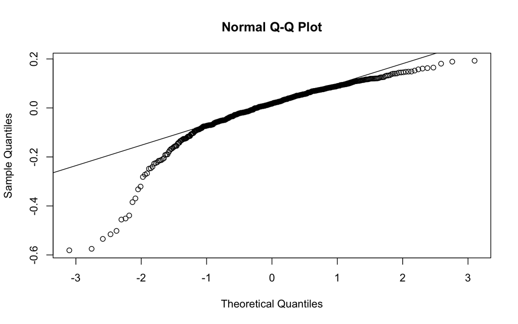

```r
# --- PLOT MODEL RESIDUALS --- #

qqnorm(resid(model))
qqline(resid(model))
```

```r
create.res.vs.fit.ecosystems(model,
                             filtered_data)
```

[interactive chart not shown]

### Dominance

#### Fixed disturbance

```r
disturbance_percentage_selected = "fixed"
```

##### 6.43 ml

```r
ecosystem_size_i = 6.43
```

```r
"Connected"
```

```
## [1] "Connected"
```

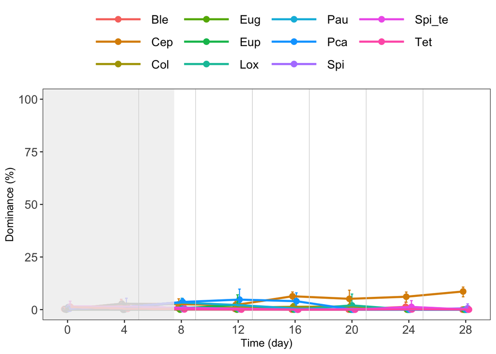

```r
print_dominance(ecosystem_size_i,
                "connected",
                disturbance_percentage_selected)
```

```r
"Unconnected"
```

```
## [1] "Unconnected"
```

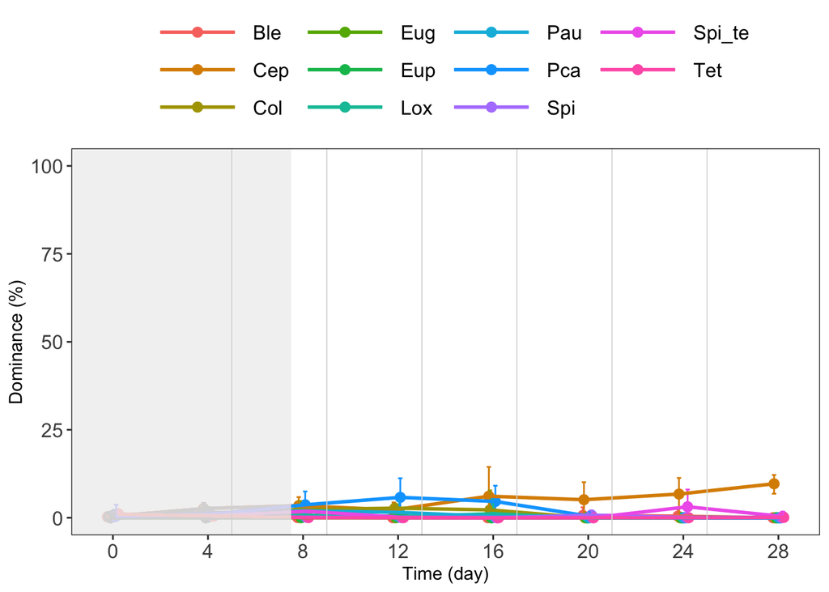

```r
print_dominance(ecosystem_size_i,
                "unconnected",
                disturbance_percentage_selected)
```

**Click to view the effect size (connected vs unconnected) with Hedge’s d**

```r
"Hedge's d"
```

```
## [1] "Hedge's d"
```

```r
for(time_point_i in 2:4){

    print(paste("Time point ", time_point_i))

    p = ds_species_effect_sizes_d %>%
      filter(connection == "connected",
             time_point == time_point_i,
             species != "Eug") %>%
      ggplot(aes(x = species,
                 y = effect_size)) +
      geom_pointrange(aes(ymin = lower_95_CI, ymax = upper_95_CI)) +
      geom_hline(yintercept = 0, linetype = "dotted") +
      theme_bw() +
      theme(panel.grid.major = element_blank(),
            panel.grid.minor = element_blank(),
            legend.position = legend_position,
            legend.key.width = unit(legend_width_cm, "cm"))

    print(p)

  }
```

[output not shown]

```
## [1] "Time point  2"
```

```
## [1] "Time point  3"
```

```
## [1] "Time point  4"
```

**Click to view the effect size (connected vs unconnected) with log response ratio (LRR)**

```r
"LRR"
```

```
## [1] "LRR"
```

```
## [1] "Time point  2"
```

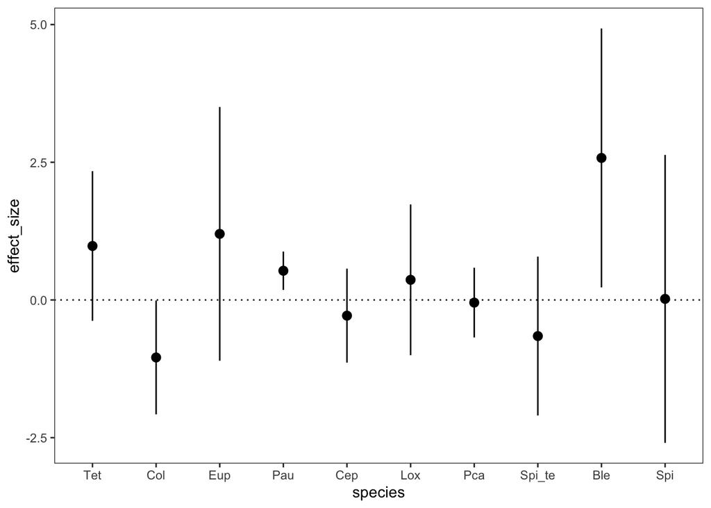

```
## [1] "Time point  3"
```

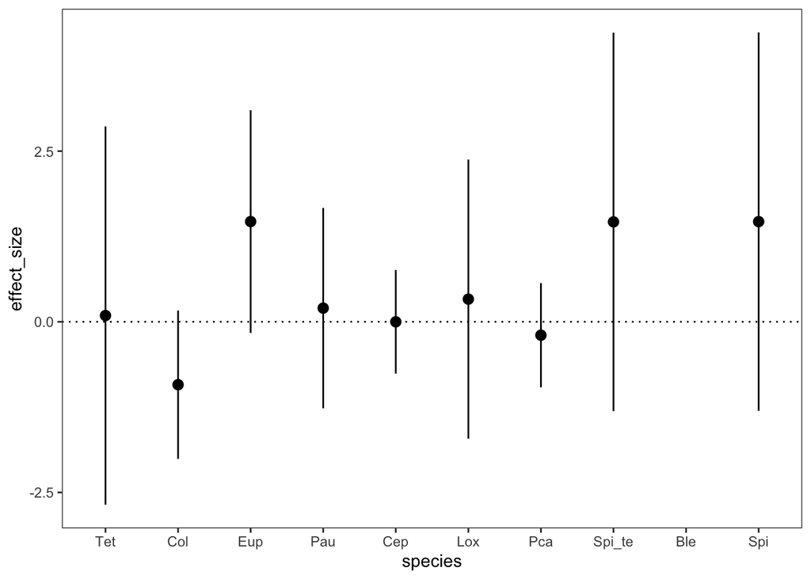

```
## [1] "Time point  4"
```

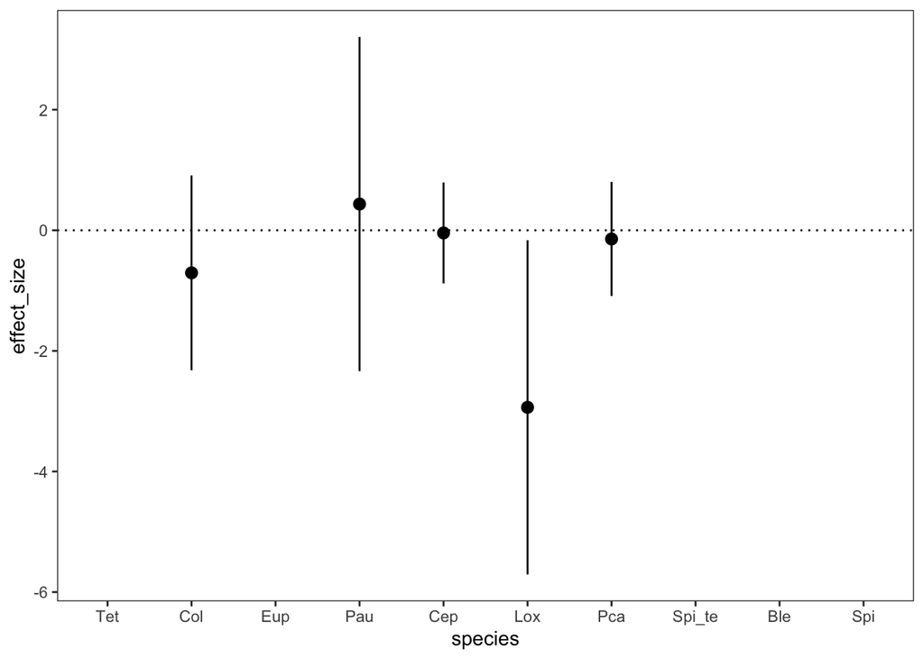

```r
for(time_point_i in 2:4){

    print(paste("Time point ", time_point_i))

    p = ds_species_effect_sizes_LRR %>%
      filter(time_point == time_point_i,
             species != "Eug",
             ecosystem_size_ml == ecosystem_size_i,
             trophic_type == "heterotrophic",
             connection == "connected",
             disturbance_percentage == disturbance_percentage_selected) %>%
      ggplot(aes(x = species,
                 y = effect_size)) +
      geom_pointrange(aes(ymin = lower_95_CI, ymax = upper_95_CI)) +
      geom_hline(yintercept = 0, linetype = "dotted") +
      theme_bw() +
      theme(panel.grid.major = element_blank(),
            panel.grid.minor = element_blank(),
            legend.position = legend_position,
            legend.key.width = unit(legend_width_cm, "cm"))

    print(p)

  }
```

##### 9.00 ml

```r
ecosystem_size_i = 9.00
```

```r
"Connected"
```

```
## [1] "Connected"
```

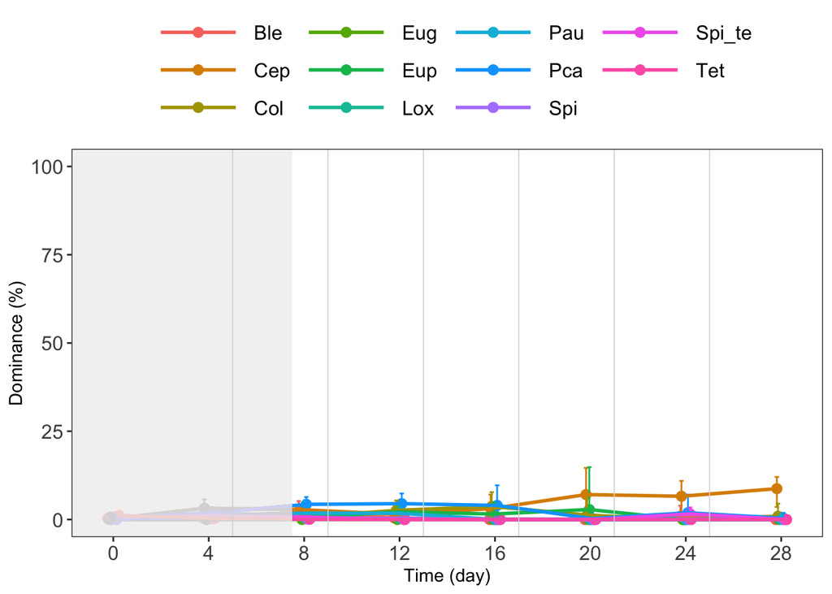

```r
print_dominance(ecosystem_size_i,
                "connected",
                disturbance_percentage_selected)
```

```r
"Unconnected"
```

```
## [1] "Unconnected"
```

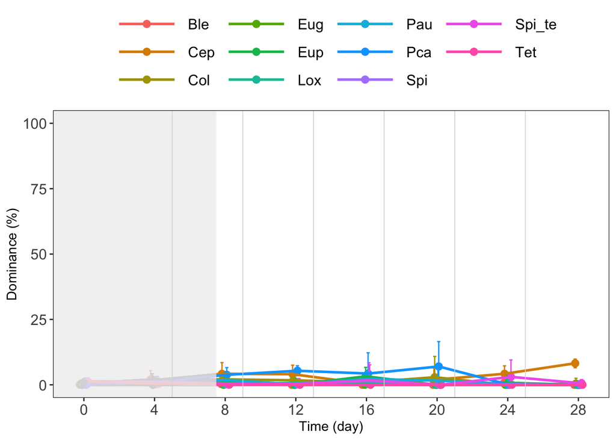

```r
print_dominance(ecosystem_size_i,
                "unconnected",
                disturbance_percentage_selected)
```

**Click to view the effect size (connected vs unconnected) with Hedge’s d**

```r
"Hedge's d"
```

```
## [1] "Hedge's d"
```

```r
for(time_point_i in 2:4){

    print(paste("Time point ", time_point_i))

    p = ds_species_effect_sizes_d %>%
      filter(connection == "connected",
             time_point == time_point_i,
             species != "Eug") %>%
      ggplot(aes(x = species,
                 y = effect_size)) +
      geom_pointrange(aes(ymin = lower_95_CI, ymax = upper_95_CI)) +
      geom_hline(yintercept = 0, linetype = "dotted") +
      theme_bw() +
      theme(panel.grid.major = element_blank(),
            panel.grid.minor = element_blank(),
            legend.position = legend_position,
            legend.key.width = unit(legend_width_cm, "cm"))

    print(p)

  }
```

[output not shown]

```
## [1] "Time point  2"
```

```
## [1] "Time point  3"
```

```
## [1] "Time point  4"
```

**Click to view the effect size (connected vs unconnected) with log response ratio (LRR)**

```r
"LRR"
```

```
## [1] "LRR"
```

```
## [1] "Time point  2"
```

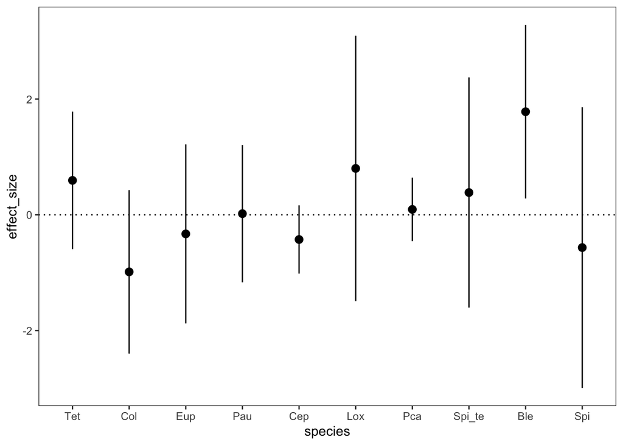

```
## [1] "Time point  3"
```

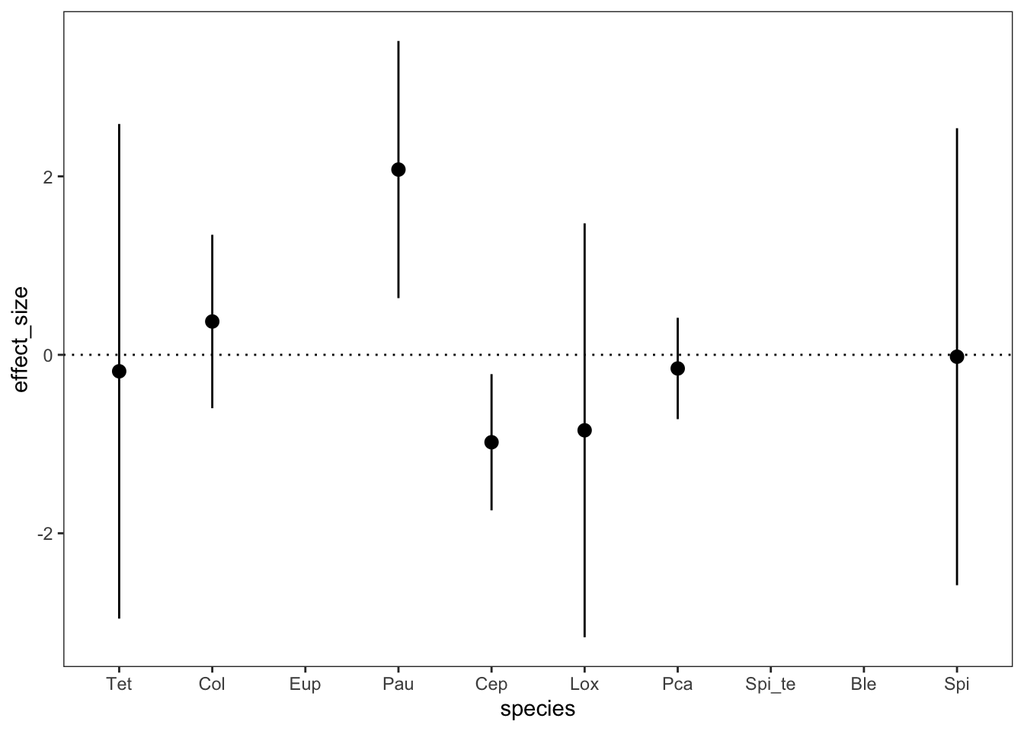

```
## [1] "Time point  4"
```

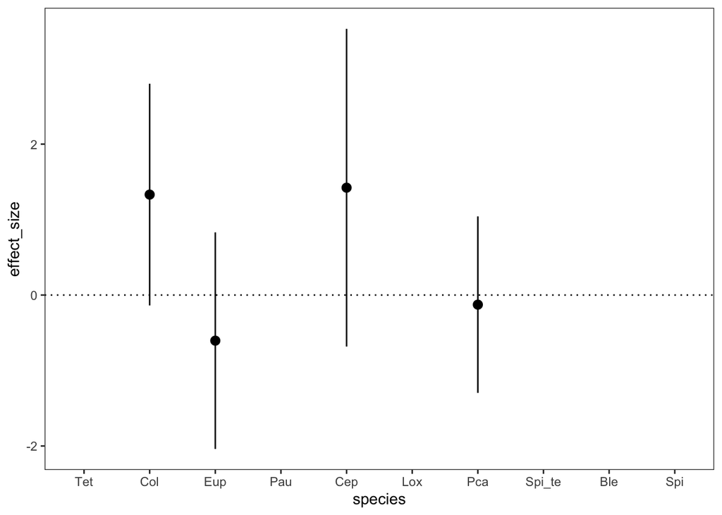

```r
for(time_point_i in 2:4){

    print(paste("Time point ", time_point_i))

    p = ds_species_effect_sizes_LRR %>%
      filter(time_point == time_point_i,
             species != "Eug",
             ecosystem_size_ml == ecosystem_size_i,
             trophic_type == "heterotrophic",
             connection == "connected",
             disturbance_percentage == disturbance_percentage_selected) %>%
      ggplot(aes(x = species,
                 y = effect_size)) +
      geom_pointrange(aes(ymin = lower_95_CI, ymax = upper_95_CI)) +
      geom_hline(yintercept = 0, linetype = "dotted") +
      theme_bw() +
      theme(panel.grid.major = element_blank(),
            panel.grid.minor = element_blank(),
            legend.position = legend_position,
            legend.key.width = unit(legend_width_cm, "cm"))

    print(p)

  }
```

##### 15.00 ml

```r
ecosystem_size_i = 15.00
```

```r
"Connected"
```

```
## [1] "Connected"
```

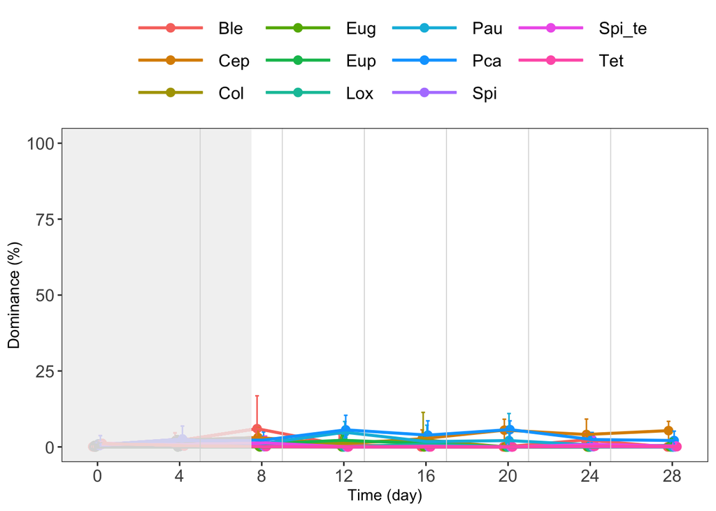

```r
print_dominance(ecosystem_size_i,
                "connected",
                disturbance_percentage_selected)
```

```r
"Unconnected"
```

```
## [1] "Unconnected"
```

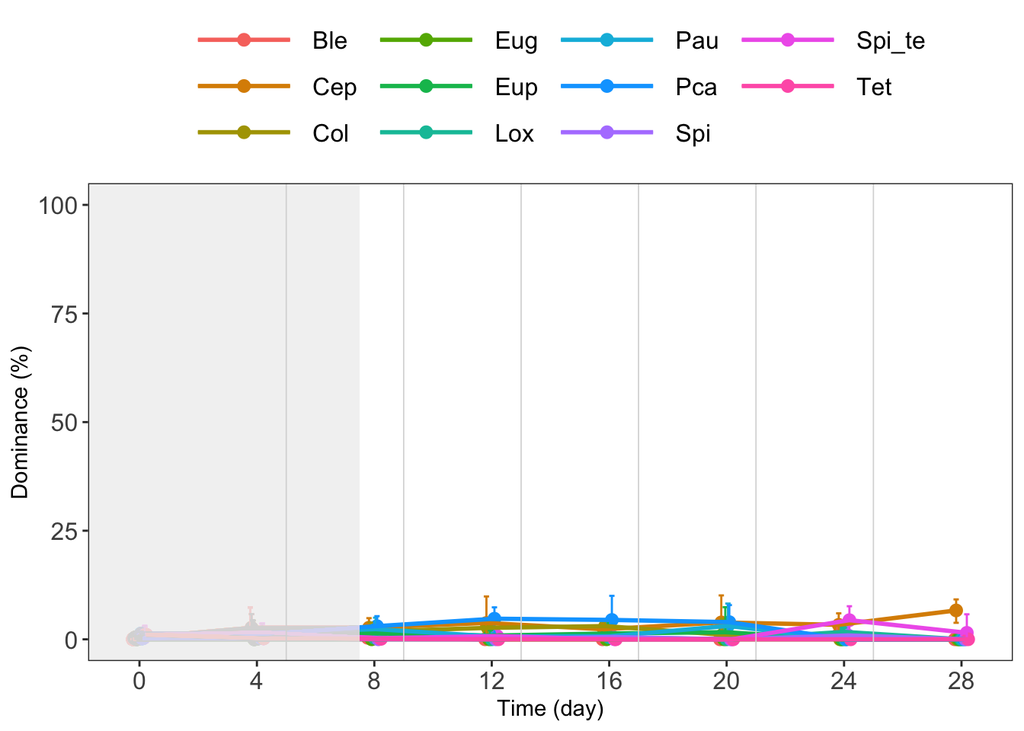

```r
print_dominance(ecosystem_size_i,
                "unconnected",
                disturbance_percentage_selected)
```

**Click to view the effect size (connected vs unconnected) with Hedge’s d**

```r
"Hedge's d"
```

```
## [1] "Hedge's d"
```

```r
for(time_point_i in 2:4){

    print(paste("Time point ", time_point_i))

    p = ds_species_effect_sizes_d %>%
      filter(connection == "connected",
             time_point == time_point_i,
             species != "Eug") %>%
      ggplot(aes(x = species,
                 y = effect_size)) +
      geom_pointrange(aes(ymin = lower_95_CI, ymax = upper_95_CI)) +
      geom_hline(yintercept = 0, linetype = "dotted") +
      theme_bw() +
      theme(panel.grid.major = element_blank(),
            panel.grid.minor = element_blank(),
            legend.position = legend_position,
            legend.key.width = unit(legend_width_cm, "cm"))

    print(p)

  }
```

[output not shown]

```
## [1] "Time point  2"
```

```
## [1] "Time point  3"
```

```
## [1] "Time point  4"
```

**Click to view the effect size (connected vs unconnected) with log response ratio (LRR)**

```r
"LRR"
```

```
## [1] "LRR"
```

```
## [1] "Time point  2"
```

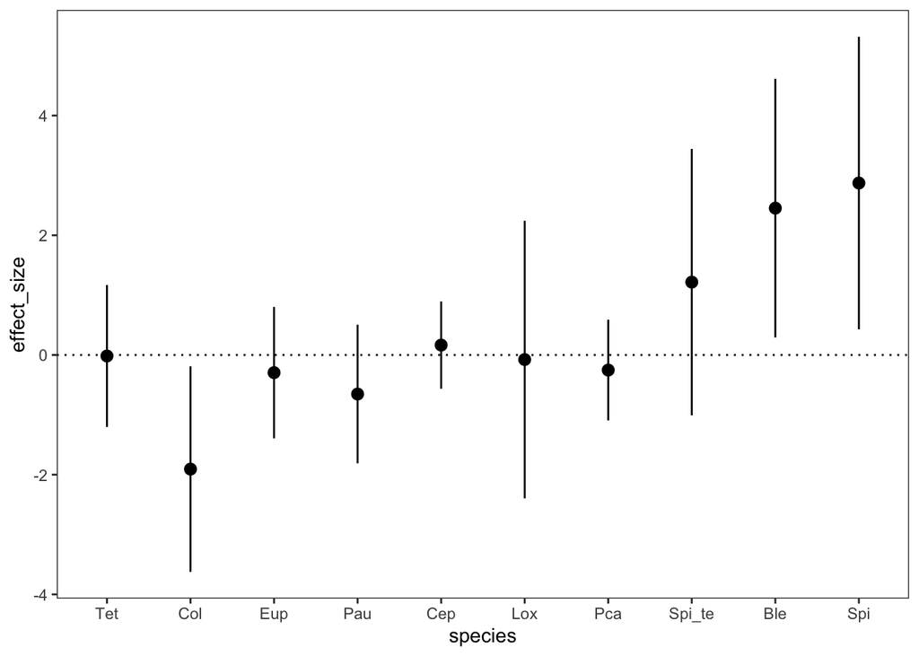

```
## [1] "Time point  3"
```

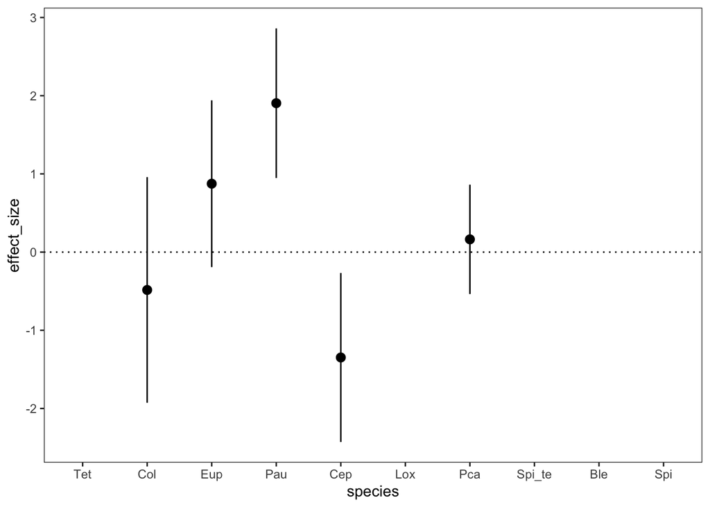

```
## [1] "Time point  4"
```

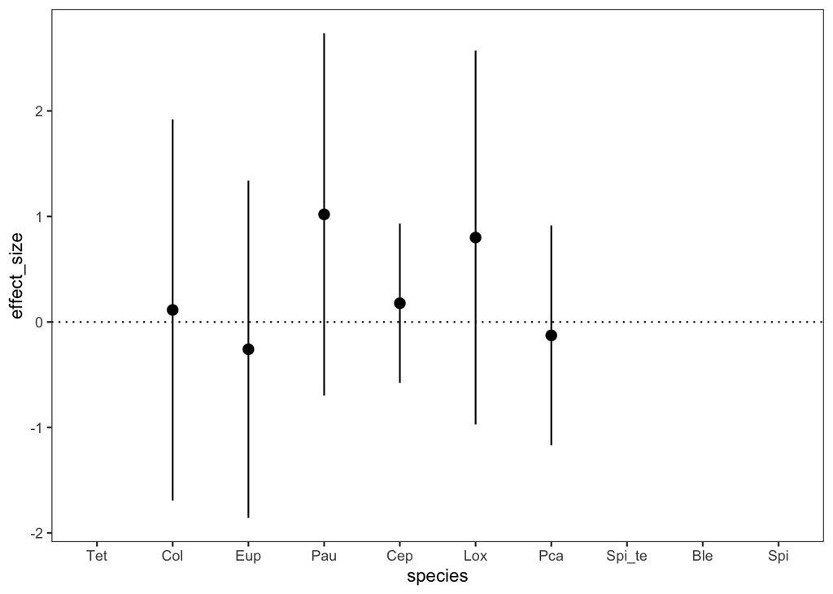

```r
for(time_point_i in 2:4){

    print(paste("Time point ", time_point_i))

    p = ds_species_effect_sizes_LRR %>%
      filter(time_point == time_point_i,
             species != "Eug",
             ecosystem_size_ml == ecosystem_size_i,
             trophic_type == "heterotrophic",
             connection == "connected",
             disturbance_percentage == disturbance_percentage_selected) %>%
      ggplot(aes(x = species,
                 y = effect_size)) +
      geom_pointrange(aes(ymin = lower_95_CI, ymax = upper_95_CI)) +
      geom_hline(yintercept = 0, linetype = "dotted") +
      theme_bw() +
      theme(panel.grid.major = element_blank(),
            panel.grid.minor = element_blank(),
            legend.position = legend_position,
            legend.key.width = unit(legend_width_cm, "cm"))

    print(p)

  }
```

##### 45.00 ml

```r
ecosystem_size_i = 45.00
```

```r
"Connected"
```

```
## [1] "Connected"
```

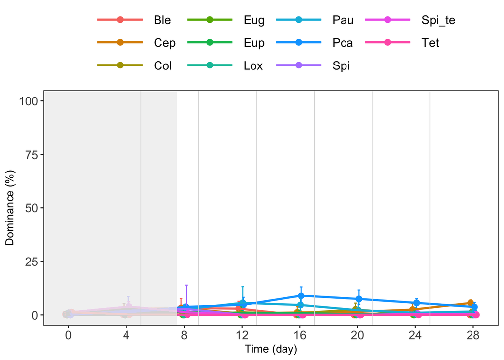

```r
print_dominance(ecosystem_size_i,
                "connected",
                disturbance_percentage_selected)
```

```r
"Unconnected"
```

```
## [1] "Unconnected"
```

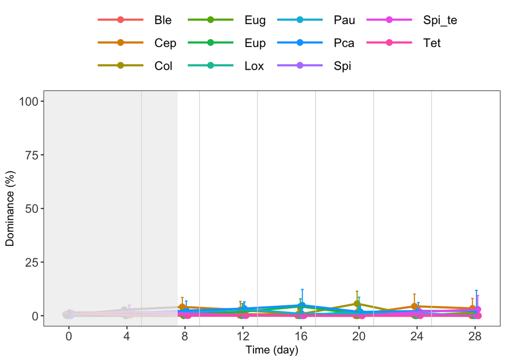

```r
print_dominance(ecosystem_size_i,
                "unconnected",
                disturbance_percentage_selected)
```

**Click to view the effect size (connected vs unconnected) with Hedge’s d**

```r
"Hedge's d"
```

```
## [1] "Hedge's d"
```

```r
for(time_point_i in 2:4){

    print(paste("Time point ", time_point_i))

    p = ds_species_effect_sizes_d %>%
      filter(connection == "connected",
             time_point == time_point_i,
             species != "Eug") %>%
      ggplot(aes(x = species,
                 y = effect_size)) +
      geom_pointrange(aes(ymin = lower_95_CI, ymax = upper_95_CI)) +
      geom_hline(yintercept = 0, linetype = "dotted") +
      theme_bw() +
      theme(panel.grid.major = element_blank(),
            panel.grid.minor = element_blank(),
            legend.position = legend_position,
            legend.key.width = unit(legend_width_cm, "cm"))

    print(p)

  }
```

[output not shown]

```
## [1] "Time point  2"
```

```
## [1] "Time point  3"
```

```
## [1] "Time point  4"
```

**Click to view the effect size (connected vs unconnected) with log response ratio (LRR)**

```r
"LRR"
```

```
## [1] "LRR"
```

```
## [1] "Time point  2"
```

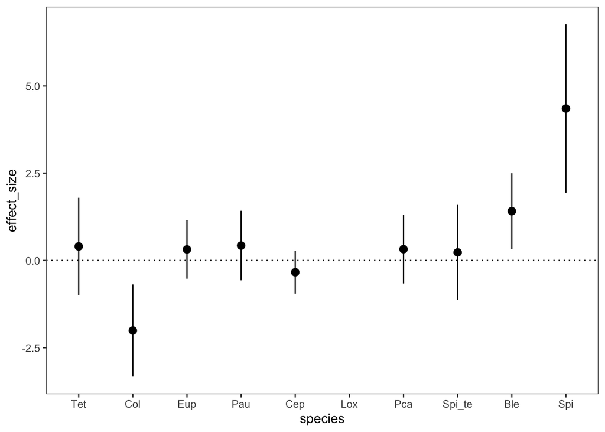

```
## [1] "Time point  3"
```

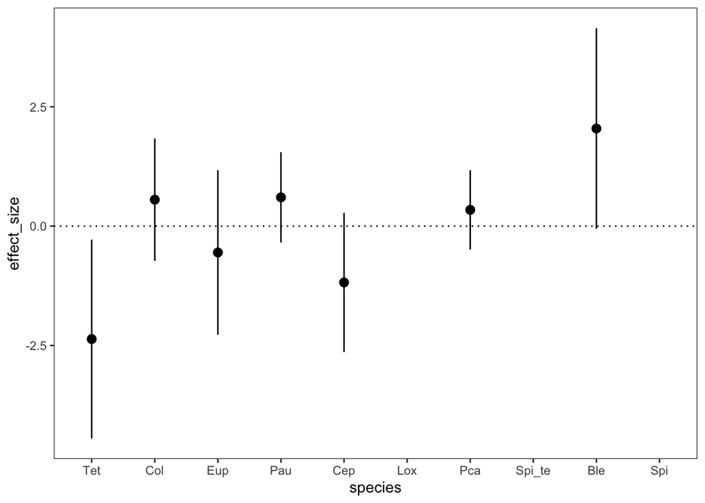

```
## [1] "Time point  4"
```

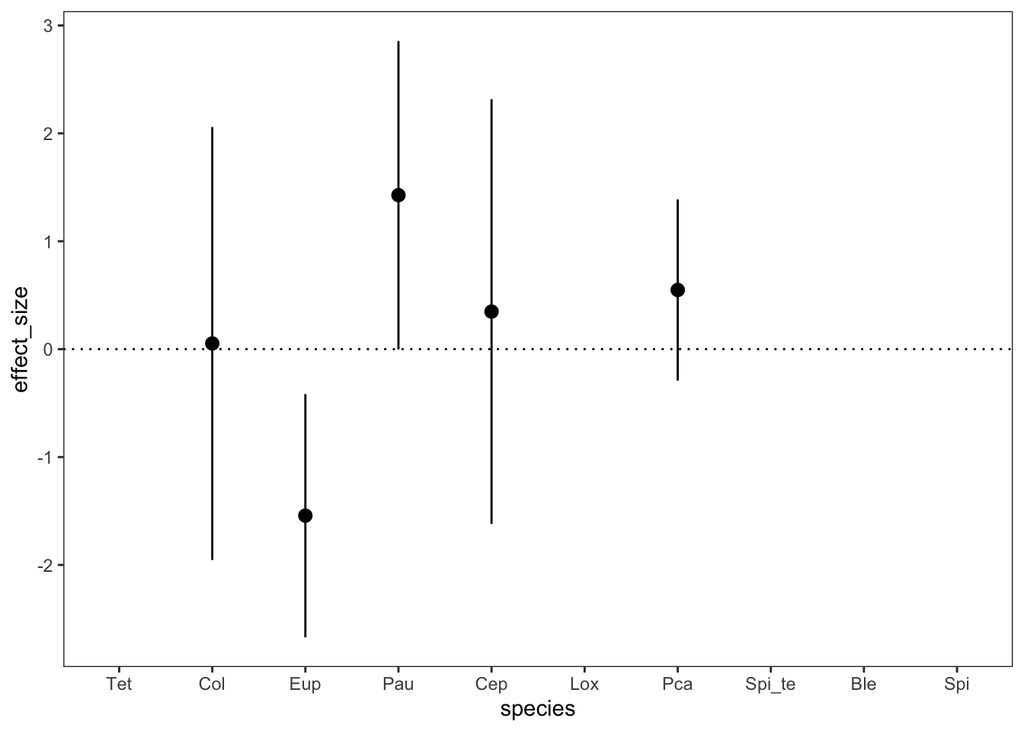

```r
for(time_point_i in 2:4){

    print(paste("Time point ", time_point_i))

    p = ds_species_effect_sizes_LRR %>%
      filter(time_point == time_point_i,
             species != "Eug",
             ecosystem_size_ml == ecosystem_size_i,
             trophic_type == "heterotrophic",
             connection == "connected",
             disturbance_percentage == disturbance_percentage_selected) %>%
      ggplot(aes(x = species,
                 y = effect_size)) +
      geom_pointrange(aes(ymin = lower_95_CI, ymax = upper_95_CI)) +
      geom_hline(yintercept = 0, linetype = "dotted") +
      theme_bw() +
      theme(panel.grid.major = element_blank(),
            panel.grid.minor = element_blank(),
            legend.position = legend_position,
            legend.key.width = unit(legend_width_cm, "cm"))

    print(p)

  }
```

##### Disturbance relative to size

```r
disturbance_percentage_selected = "decreasing_with_size"
```

###### 6.43 ml

```r
ecosystem_size_i = 6.43
```

```r
"Connected"
```

```
## [1] "Connected"
```

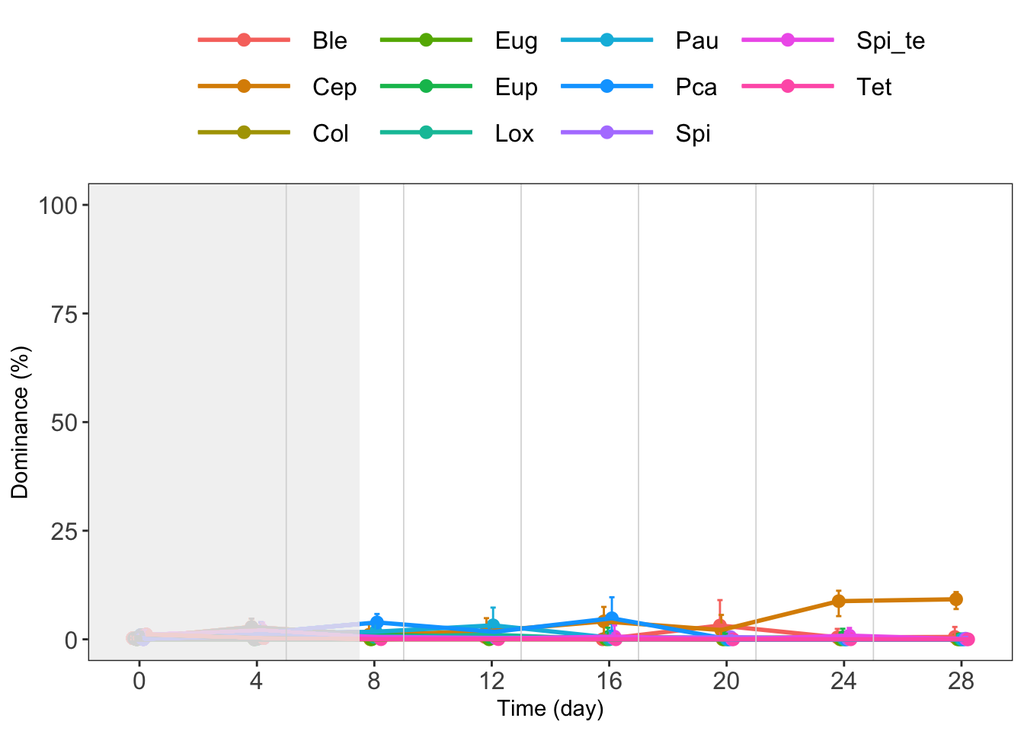

```r
print_dominance(ecosystem_size_i,
                "connected",
                disturbance_percentage_selected)
```

```r
"Unconnected"
```

```
## [1] "Unconnected"
```

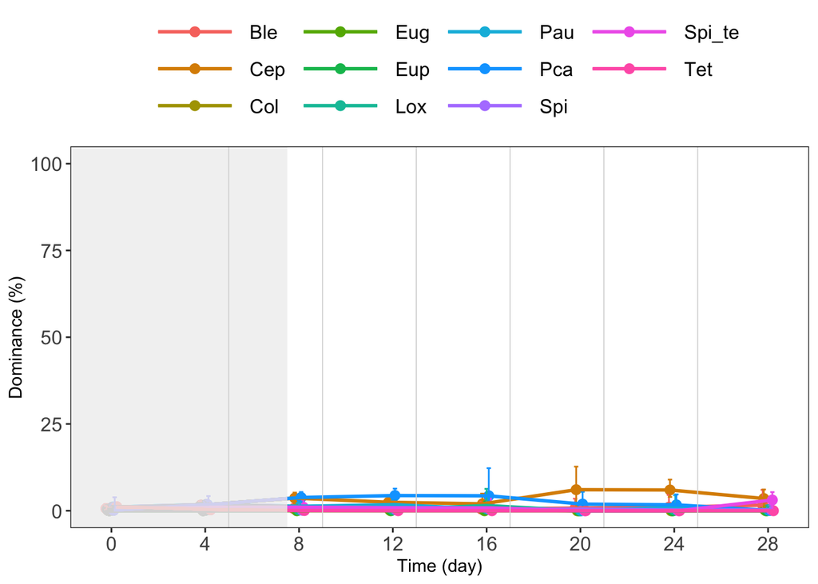

```r
print_dominance(ecosystem_size_i,
                "unconnected",
                disturbance_percentage_selected)
```

**Click to view the effect size (connected vs unconnected) with Hedge’s d**

```r
"Hedge's d"
```

```
## [1] "Hedge's d"
```

```r
for(time_point_i in 2:4){

    print(paste("Time point ", time_point_i))

    p = ds_species_effect_sizes_d %>%
      filter(connection == "connected",
             time_point == time_point_i,
             species != "Eug") %>%
      ggplot(aes(x = species,
                 y = effect_size)) +
      geom_pointrange(aes(ymin = lower_95_CI, ymax = upper_95_CI)) +
      geom_hline(yintercept = 0, linetype = "dotted") +
      theme_bw() +
      theme(panel.grid.major = element_blank(),
            panel.grid.minor = element_blank(),
            legend.position = legend_position,
            legend.key.width = unit(legend_width_cm, "cm"))

    print(p)

  }
```

[output not shown]

```
## [1] "Time point  2"
```

```
## [1] "Time point  3"
```

```
## [1] "Time point  4"
```

**Click to view the effect size (connected vs unconnected) with log response ratio (LRR)**

```r
"LRR"
```

```
## [1] "LRR"
```

```
## [1] "Time point  2"
```

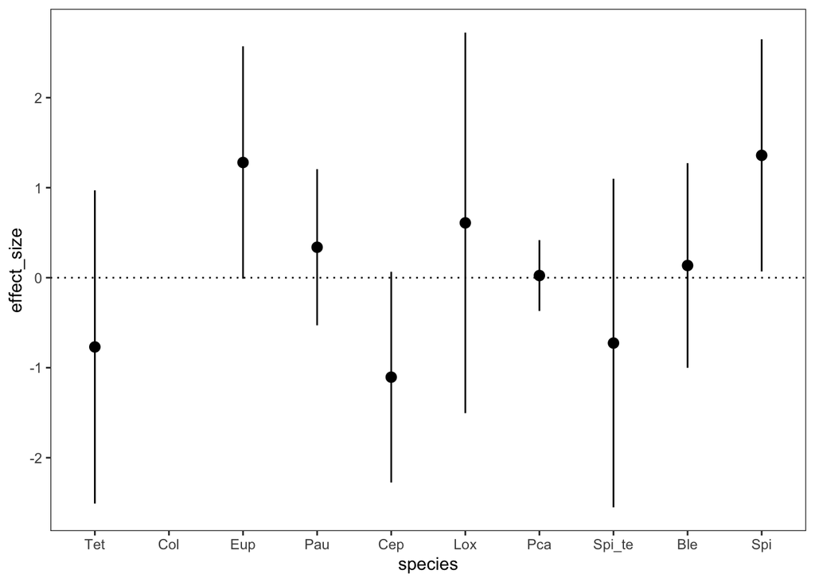

```
## [1] "Time point  3"
```

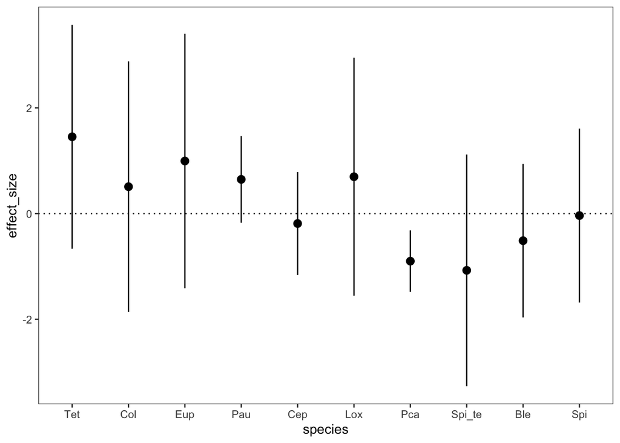

```
## [1] "Time point  4"
```

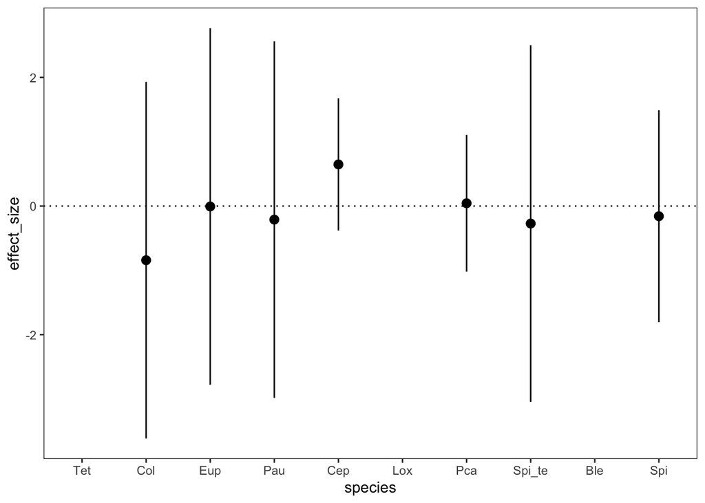

```r
for(time_point_i in 2:4){

    print(paste("Time point ", time_point_i))

    p = ds_species_effect_sizes_LRR %>%
      filter(time_point == time_point_i,
             species != "Eug",
             ecosystem_size_ml == ecosystem_size_i,
             trophic_type == "heterotrophic",
             connection == "connected",
             disturbance_percentage == disturbance_percentage_selected) %>%
      ggplot(aes(x = species,
                 y = effect_size)) +
      geom_pointrange(aes(ymin = lower_95_CI, ymax = upper_95_CI)) +
      geom_hline(yintercept = 0, linetype = "dotted") +
      theme_bw() +
      theme(panel.grid.major = element_blank(),
            panel.grid.minor = element_blank(),
            legend.position = legend_position,
            legend.key.width = unit(legend_width_cm, "cm"))

    print(p)

  }
```

###### 9.00 ml

```r
ecosystem_size_i = 9.00
```

```r
"Connected"
```

```
## [1] "Connected"
```

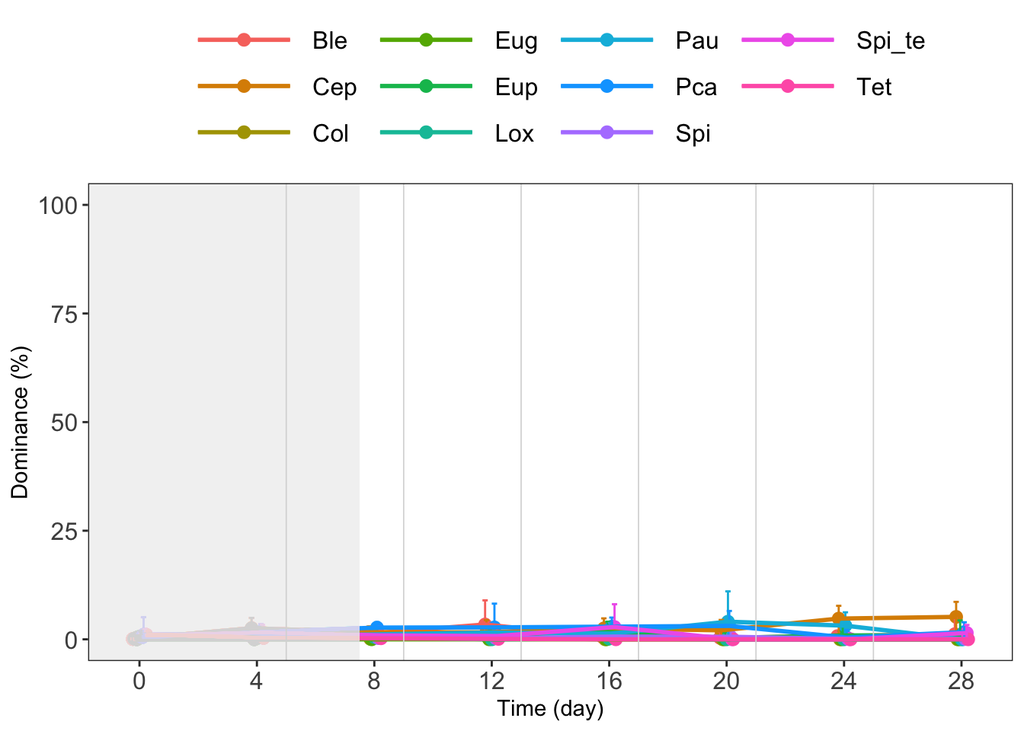

```r
print_dominance(ecosystem_size_i,
                "connected",
                disturbance_percentage_selected)
```

```r
"Unconnected"
```

```
## [1] "Unconnected"
```

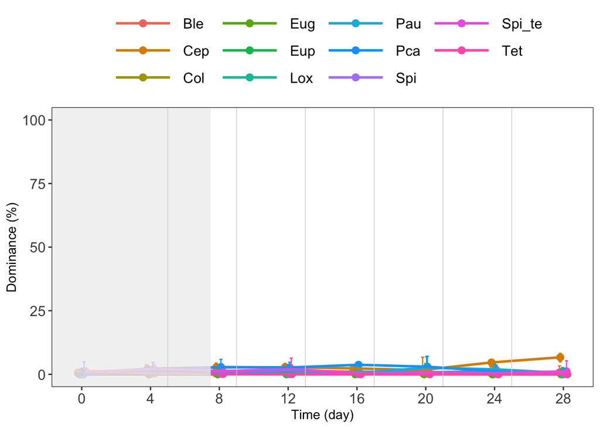

```r
print_dominance(ecosystem_size_i,
                "unconnected",
                disturbance_percentage_selected)
```

**Click to view the effect size (connected vs unconnected) with Hedge’s d**

```r
"Hedge's d"
```

```
## [1] "Hedge's d"
```

```r
for(time_point_i in 2:4){

    print(paste("Time point ", time_point_i))

    p = ds_species_effect_sizes_d %>%
      filter(connection == "connected",
             time_point == time_point_i,
             species != "Eug") %>%
      ggplot(aes(x = species,
                 y = effect_size)) +
      geom_pointrange(aes(ymin = lower_95_CI, ymax = upper_95_CI)) +
      geom_hline(yintercept = 0, linetype = "dotted") +
      theme_bw() +
      theme(panel.grid.major = element_blank(),
            panel.grid.minor = element_blank(),
            legend.position = legend_position,
            legend.key.width = unit(legend_width_cm, "cm"))

    print(p)

  }
```

[output not shown]

```
## [1] "Time point  2"
```

```
## [1] "Time point  3"
```

```
## [1] "Time point  4"
```

**Click to view the effect size (connected vs unconnected) with log response ratio (LRR)**

```r
"LRR"
```

```
## [1] "LRR"
```

```
## [1] "Time point  2"
```

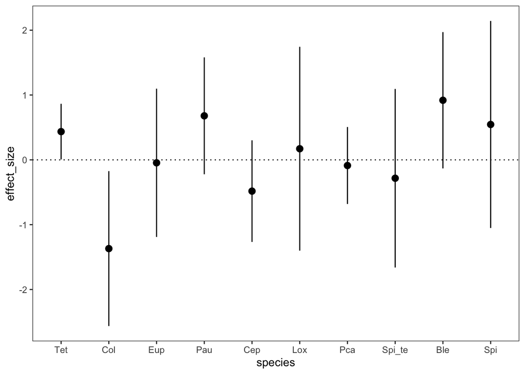

```
## [1] "Time point  3"
```

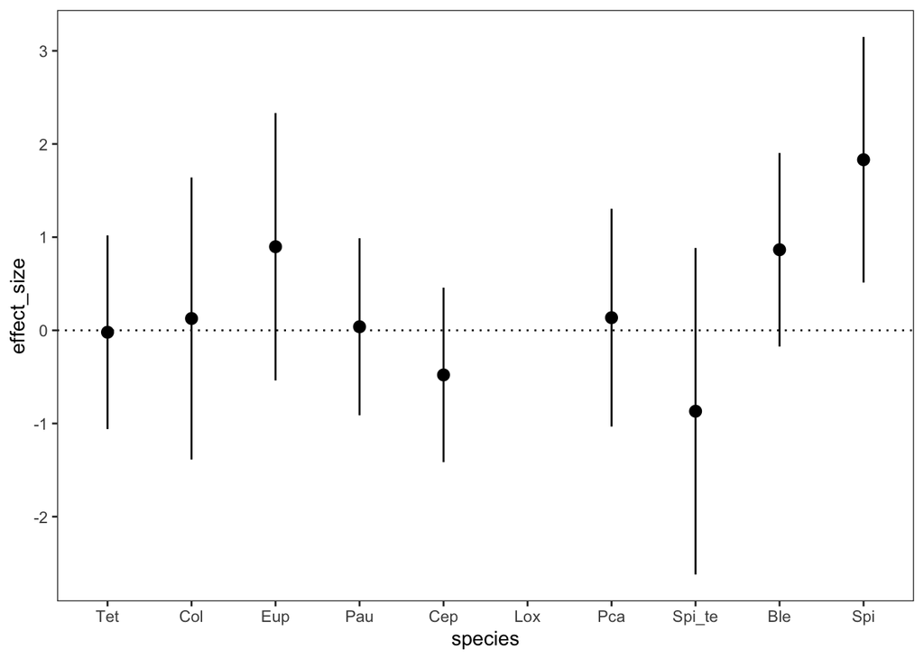

```
## [1] "Time point  4"
```

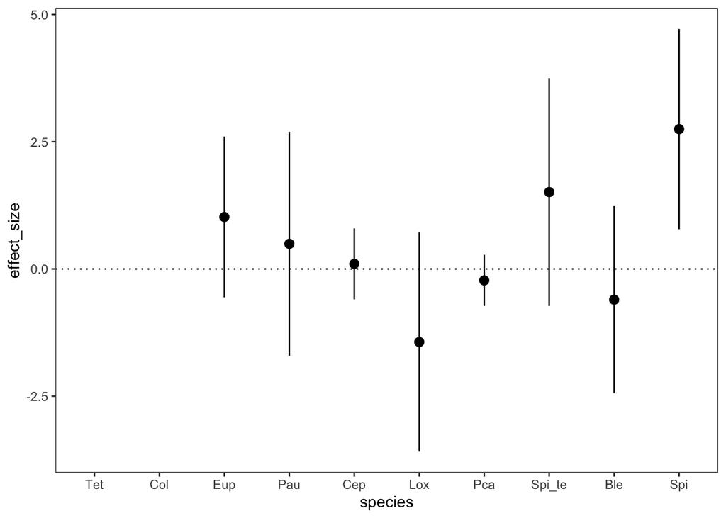

```r
for(time_point_i in 2:4){

    print(paste("Time point ", time_point_i))

    p = ds_species_effect_sizes_LRR %>%
      filter(time_point == time_point_i,
             species != "Eug",
             ecosystem_size_ml == ecosystem_size_i,
             trophic_type == "heterotrophic",
             connection == "connected",
             disturbance_percentage == disturbance_percentage_selected) %>%
      ggplot(aes(x = species,
                 y = effect_size)) +
      geom_pointrange(aes(ymin = lower_95_CI, ymax = upper_95_CI)) +
      geom_hline(yintercept = 0, linetype = "dotted") +
      theme_bw() +
      theme(panel.grid.major = element_blank(),
            panel.grid.minor = element_blank(),
            legend.position = legend_position,
            legend.key.width = unit(legend_width_cm, "cm"))

    print(p)

  }
```

###### 15.00 ml

```r
ecosystem_size_i = 15.00
```

```r
"Connected"
```

```
## [1] "Connected"
```

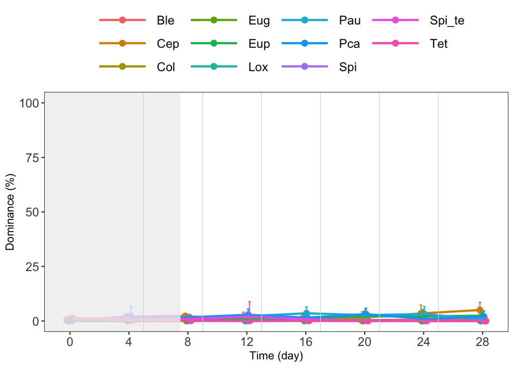

```r
print_dominance(ecosystem_size_i,
                "connected",
                disturbance_percentage_selected)
```

```r
"Unconnected"
```

```
## [1] "Unconnected"
```

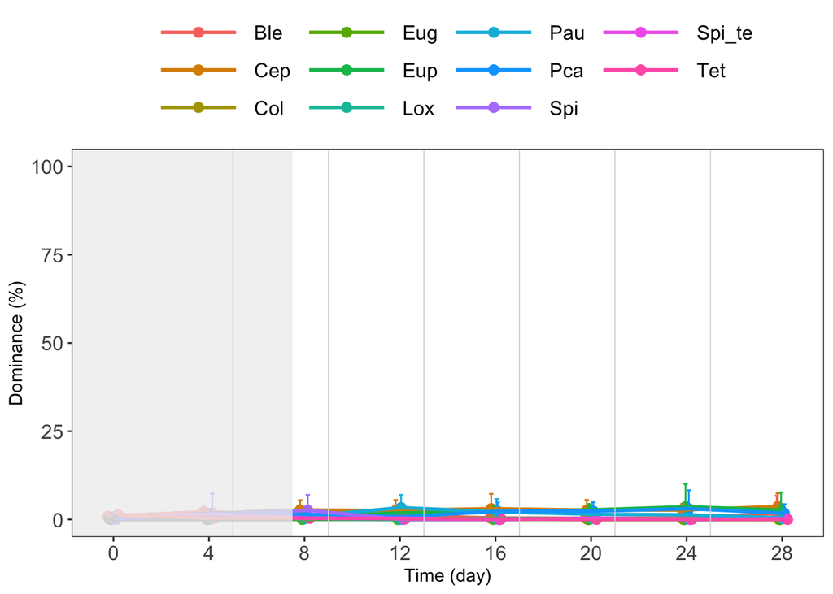

```r
print_dominance(ecosystem_size_i,
                "unconnected",
                disturbance_percentage_selected)
```

**Click to view the effect size (connected vs unconnected) with Hedge’s d**

```r
"Hedge's d"
```

```
## [1] "Hedge's d"
```

```r
for(time_point_i in 2:4){

    print(paste("Time point ", time_point_i))

    p = ds_species_effect_sizes_d %>%
      filter(connection == "connected",
             time_point == time_point_i,
             species != "Eug") %>%
      ggplot(aes(x = species,
                 y = effect_size)) +
      geom_pointrange(aes(ymin = lower_95_CI, ymax = upper_95_CI)) +
      geom_hline(yintercept = 0, linetype = "dotted") +
      theme_bw() +
      theme(panel.grid.major = element_blank(),
            panel.grid.minor = element_blank(),
            legend.position = legend_position,
            legend.key.width = unit(legend_width_cm, "cm"))

    print(p)

  }
```

[output not shown]

```
## [1] "Time point  2"
```

```
## [1] "Time point  3"
```

```
## [1] "Time point  4"
```

**Click to view the effect size (connected vs unconnected) with log response ratio (LRR)**

```r
"LRR"
```

```
## [1] "LRR"
```

```
## [1] "Time point  2"
```

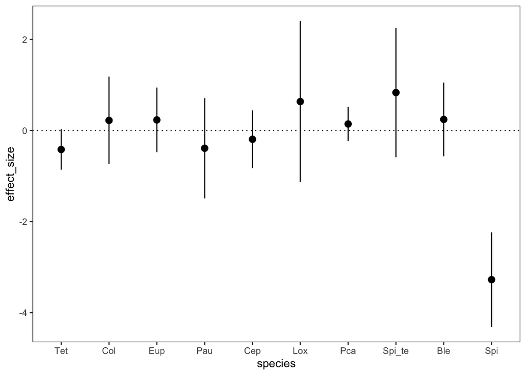

```
## [1] "Time point  3"
```

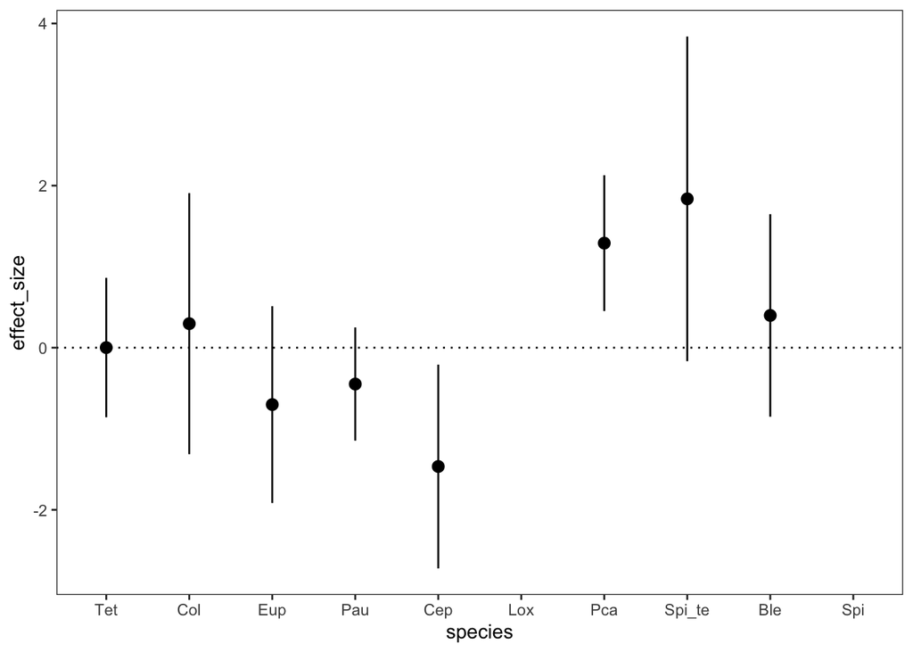

```
## [1] "Time point  4"
```

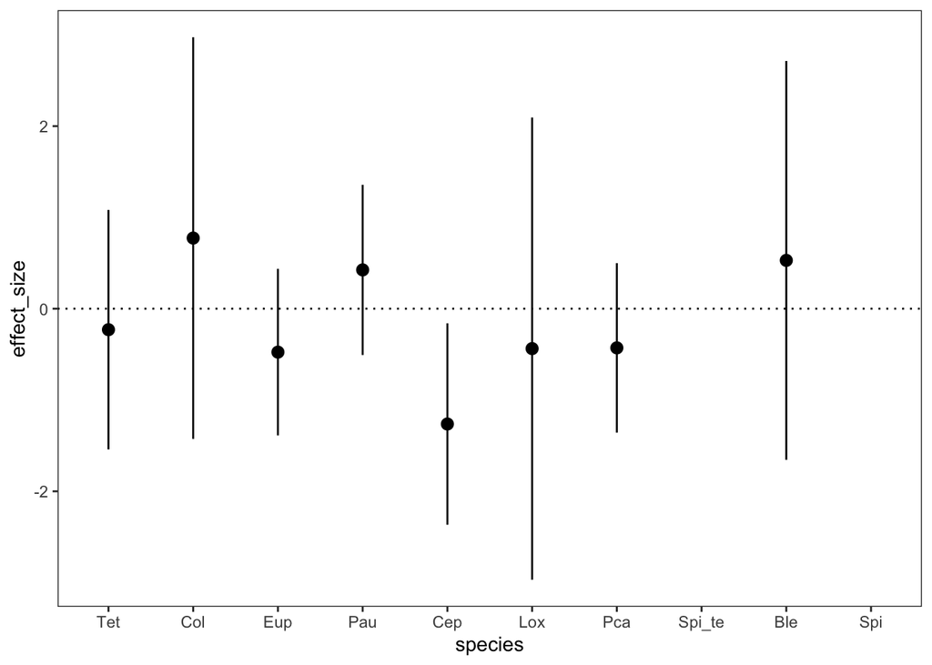

```r
for(time_point_i in 2:4){

    print(paste("Time point ", time_point_i))

    p = ds_species_effect_sizes_LRR %>%
      filter(time_point == time_point_i,
             species != "Eug",
             ecosystem_size_ml == ecosystem_size_i,
             trophic_type == "heterotrophic",
             connection == "connected",
             disturbance_percentage == disturbance_percentage_selected) %>%
      ggplot(aes(x = species,
                 y = effect_size)) +
      geom_pointrange(aes(ymin = lower_95_CI, ymax = upper_95_CI)) +
      geom_hline(yintercept = 0, linetype = "dotted") +
      theme_bw() +
      theme(panel.grid.major = element_blank(),
            panel.grid.minor = element_blank(),
            legend.position = legend_position,
            legend.key.width = unit(legend_width_cm, "cm"))

    print(p)

  }
```

###### 45.00 ml

```r
ecosystem_size_i = 45.00
```

```r
"Connected"
```

```
## [1] "Connected"
```

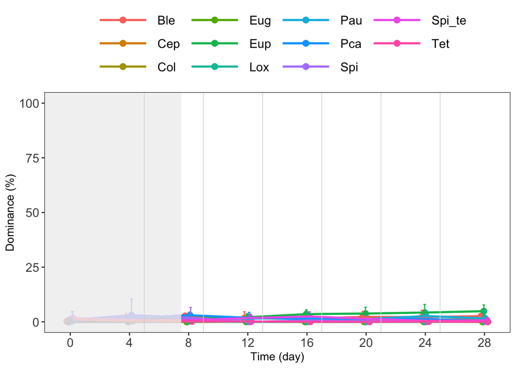

```r
print_dominance(ecosystem_size_i,
                "connected",
                disturbance_percentage_selected)
```

```r
"Unconnected"
```

```
## [1] "Unconnected"
```

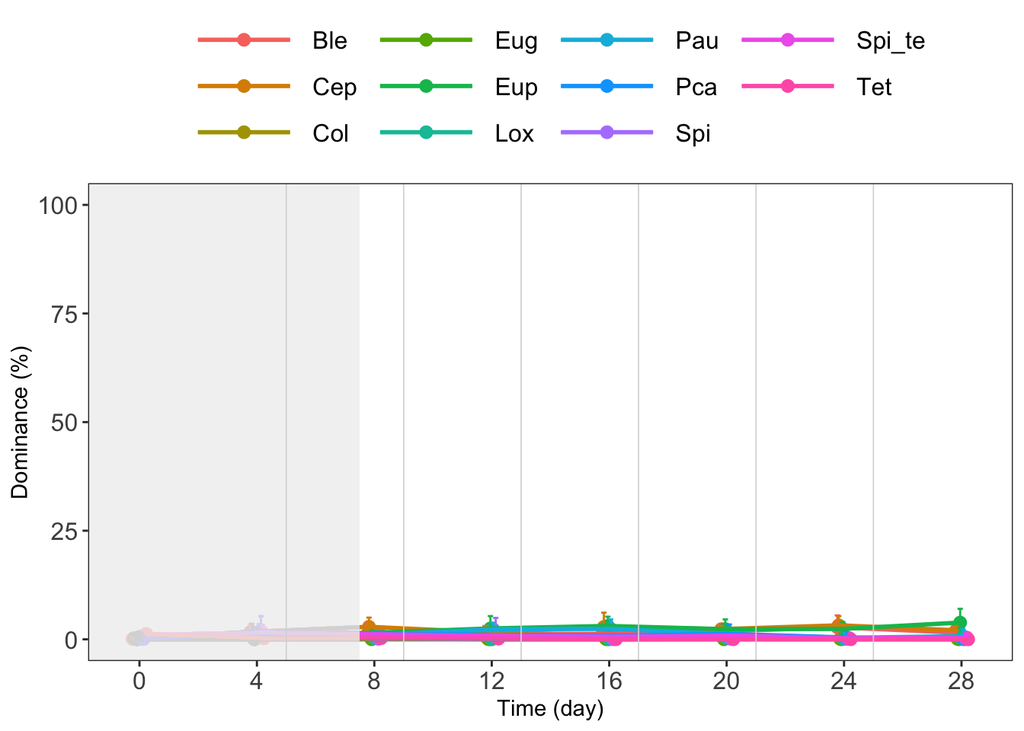

```r
print_dominance(ecosystem_size_i,
                "unconnected",
                disturbance_percentage_selected)
```

**Click to view the effect size (connected vs unconnected) with Hedge’s d**

```r
"Hedge's d"
```

```
## [1] "Hedge's d"
```

```r
for(time_point_i in 2:4){

    print(paste("Time point ", time_point_i))

    p = ds_species_effect_sizes_d %>%
      filter(connection == "connected",
             time_point == time_point_i,
             species != "Eug") %>%
      ggplot(aes(x = species,
                 y = effect_size)) +
      geom_pointrange(aes(ymin = lower_95_CI, ymax = upper_95_CI)) +
      geom_hline(yintercept = 0, linetype = "dotted") +
      theme_bw() +
      theme(panel.grid.major = element_blank(),
            panel.grid.minor = element_blank(),
            legend.position = legend_position,
            legend.key.width = unit(legend_width_cm, "cm"))

    print(p)

  }
```

[output not shown]

```
## [1] "Time point  2"
```

```
## [1] "Time point  3"
```

```
## [1] "Time point  4"
```

**Click to view the effect size (connected vs unconnected) with log response ratio (LRR)**

```r
"LRR"
```

```
## [1] "LRR"
```

```
## [1] "Time point  2"
```

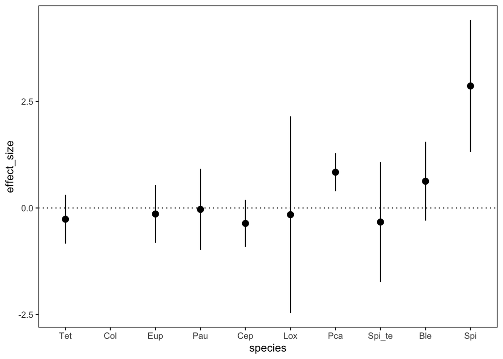

```
## [1] "Time point  3"
```

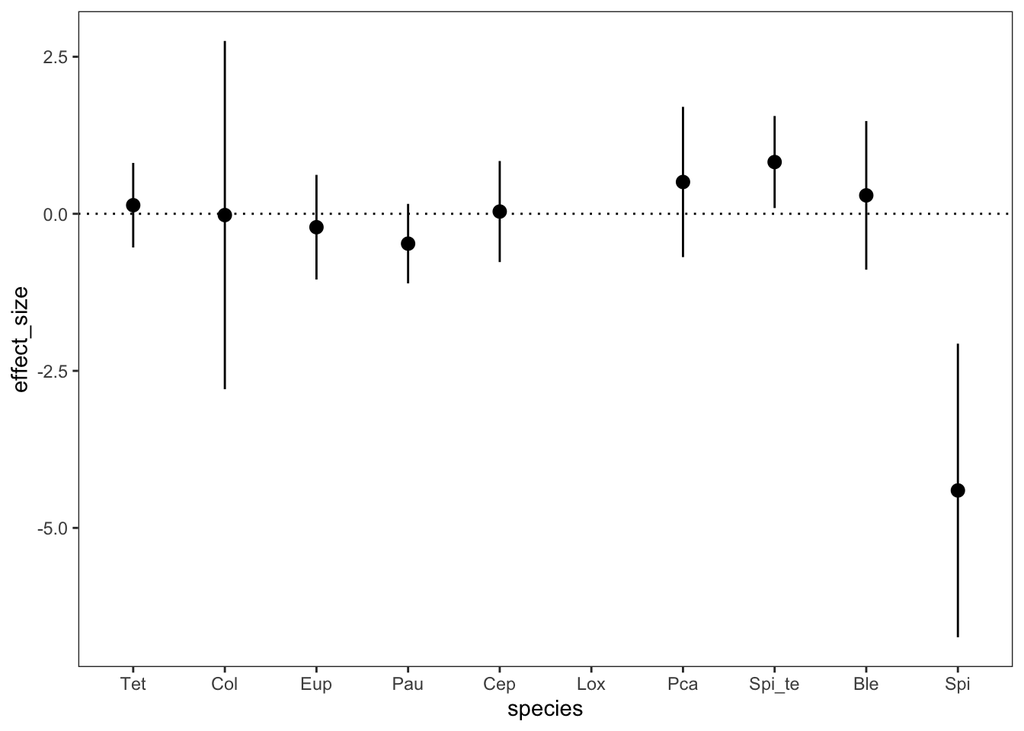

```
## [1] "Time point  4"
```

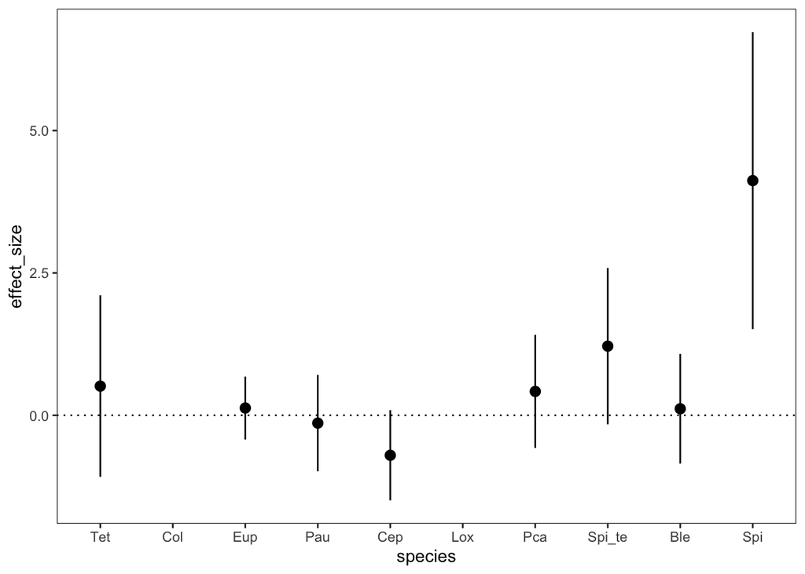

```r
for(time_point_i in 2:4){

    print(paste("Time point ", time_point_i))

    p = ds_species_effect_sizes_LRR %>%
      filter(time_point == time_point_i,
             species != "Eug",
             ecosystem_size_ml == ecosystem_size_i,
             trophic_type == "heterotrophic",
             connection == "connected",
             disturbance_percentage == disturbance_percentage_selected) %>%
      ggplot(aes(x = species,
                 y = effect_size)) +
      geom_pointrange(aes(ymin = lower_95_CI, ymax = upper_95_CI)) +
      geom_hline(yintercept = 0, linetype = "dotted") +
      theme_bw() +
      theme(panel.grid.major = element_blank(),
            panel.grid.minor = element_blank(),
            legend.position = legend_position,
            legend.key.width = unit(legend_width_cm, "cm"))

    print(p)

  }
```

#### BEF

We want to know whether there was a correlation between biodiversity (richness/shannon/eveness) and productivity. We include all the time points in all the heterotrophic ecosystems (small/medium/large, connected/unconnected).

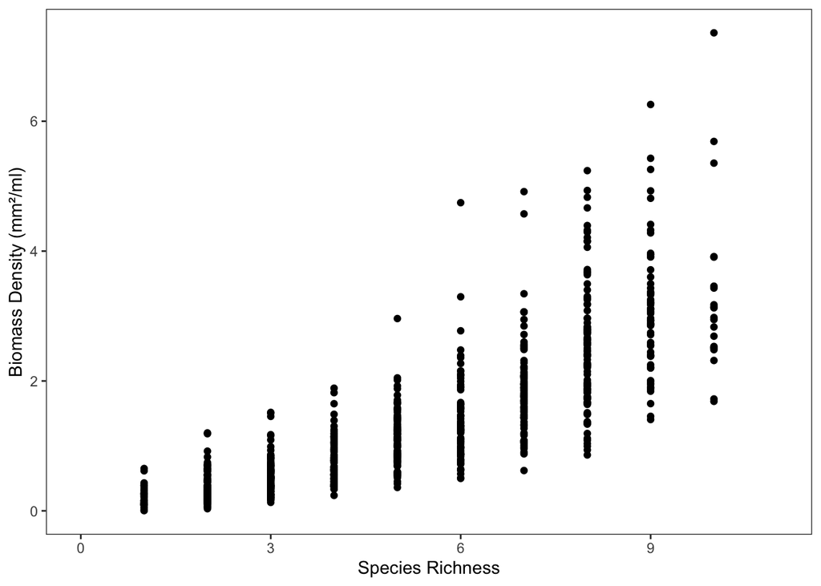

```r
ds_ecosystems %>%
  filter(trophic_type == "heterotrophic") %>%
  ggplot(aes(x = species_richness,
             y = bioarea_mm2_per_ml)) +
  geom_point() +
  xlim(0, length(protist_species)) +
  labs(x = axis_names$axis_name[axis_names$variable == "species_richness"],
       y = axis_names$axis_name[axis_names$variable == "bioarea_mm2_per_ml"]) +
  theme_bw() +
    theme(panel.grid.major = element_blank(),
          panel.grid.minor = element_blank(),
          legend.position = legend_position,
          legend.key.width = unit(legend_width_cm, "cm"))
```

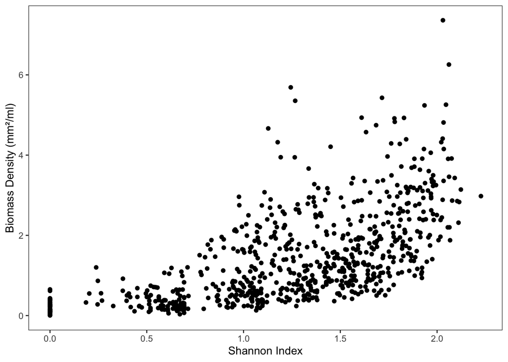

```r
ds_ecosystems %>%
  filter(trophic_type == "heterotrophic") %>%
  ggplot(aes(x = shannon,
             y = bioarea_mm2_per_ml)) +
  geom_point() +
  labs(x = axis_names$axis_name[axis_names$variable == "shannon"],
       y = axis_names$axis_name[axis_names$variable == "bioarea_mm2_per_ml"]) +
  theme_bw() +
    theme(panel.grid.major = element_blank(),
          panel.grid.minor = element_blank(),
          legend.position = legend_position,
          legend.key.width = unit(legend_width_cm, "cm"))
```

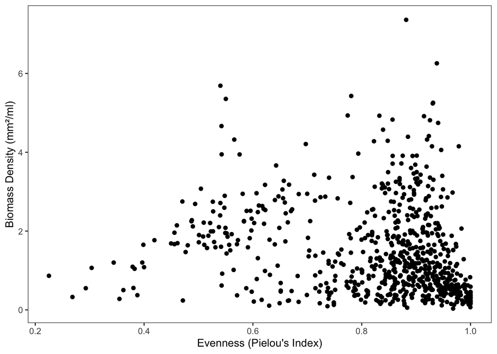

```r
ds_ecosystems %>%
  filter(trophic_type == "heterotrophic",
         is.na(evenness_pielou) != TRUE) %>%
  ggplot(aes(x = evenness_pielou,
             y = bioarea_mm2_per_ml)) +
  geom_point() +
  labs(x = axis_names$axis_name[axis_names$variable == "evenness_pielou"],
       y = axis_names$axis_name[axis_names$variable == "bioarea_mm2_per_ml"]) +
  theme_bw() +
    theme(panel.grid.major = element_blank(),
          panel.grid.minor = element_blank(),
          legend.position = legend_position,
          legend.key.width = unit(legend_width_cm, "cm"))
```

## Other

### Running time

```r
end_time = Sys.time()
round(end_time - start_time, digits = 1)
```

```
## Time difference of 1.9 mins
```

### Useful code

If you want to change a certain part of the code using the following code in Unix:

```r
#Rmd script
cd /Users/ema/Documents/GitHub/RelativeSize/r_files
sed -i '' 's/old_string/new_string/g' *.Rmd

#R script
cd /Users/ema/Documents/GitHub/RelativeSize/r_files/functions
sed -i '' 's/old_string/new_string/g' *.R
```

If you want to share a dataset and get a reproducible object, use the following R code:

```r
dput()
```

If you want to create a hidden section:

```r
<details>
<summary>Click here to .../summary>
</details>
```

Save files to calculate the effect size of meta-ecosystems.

```r
write.csv(combination_sets_isolated_systems,
          file = here("files_for_ds_metaecos_es", "combination_sets_isolated_systems.csv"))

write.csv(ds_metaecosystems,
          file = here("files_for_ds_metaecos_es", "ds_metaecosystems.csv"))

write.csv(ds_metaecosystems,
          file = here("files_for_ds_metaecos_es", "ds_metaecosystems.csv"))
```

## Bibliography

Borenstein, Michael, Larry V. Hedges, Julian P. T. Higgins, and Hannah Rothstein. 2009. *Introduction to Meta-Analysis*. John Wiley & Sons.

Hedges, Larry V., and Ingram Olkin. 1985. *Statistical Methods for Meta-Analysis*. Elsevier. https://doi.org/10.1016/C2009-0-03396-0.

Rosenberg, Michael S., Hannah R. Rothstein, and Jessica Gurevitch. 2013. “Effect Sizes: Conventional Choices and Calculations.” In *Handbook of Meta-Analysis in Ecology and Evolution*, 61–71. https://doi.org/10.23943/princeton/9780691137285.003.0006.